# ANCOVA in Vocabulario Ensinado (Vocabulario Ensinado)

Geiser C. Challco geiser@alumni.usp.br

- Descriptive Statistics of Initial Data
- ANCOVA and Pairwise for one factor: **grupo**
  - Without remove non-normal data
  - Computing ANCOVA and PairWise After removing non-normal data (OK)
    - Plots for ancova
    - Checking linearity assumption
    - Checking normality and homogeneity
- ANCOVA and Pairwise for two factors **grupo:Sexo**
  - Without remove non-normal data
  - Computing ANCOVA and PairWise After removing non-normal data (OK)
    - Plots for ancova
    - Checking linearity assumption
    - Checking normality and homogeneity
- ANCOVA and Pairwise for two factors **grupo:Zona**
  - Without remove non-normal data
  - Computing ANCOVA and PairWise After removing non-normal data (OK)
    - Plots for ancova
    - Checking linearity assumption
    - Checking normality and homogeneity
- ANCOVA and Pairwise for two factors **grupo:Cor.Raca**
  - Without remove non-normal data
  - Computing ANCOVA and PairWise After removing non-normal data (OK)
    - Plots for ancova
    - Checking linearity assumption
    - Checking normality and homogeneity
- ANCOVA and Pairwise for two factors **grupo:vocab.teach.quintile**
  - Without remove non-normal data
  - Computing ANCOVA and PairWise After removing non-normal data (OK)
    - Plots for ancova
    - Checking linearity assumption
    - Checking normality and homogeneity
- Summary of Results
  - Descriptive Statistics
  - ANCOVA Table Comparison
  - PairWise Table Comparison
  - EMMS Table Comparison

**NOTE**:

- Teste ANCOVA para determinar se houve diferenças significativas no Vocabulario Ensinado (medido usando pre- e pos-testes).
- ANCOVA test to determine whether there were significant differences in Vocabulario Ensinado (measured using pre- and post-tests).

# Descriptive Statistics of Initial Data

```r
df <- get.descriptives(dat, c(dv.pre, dv.pos), c("grupo"),
                       include.global = T, symmetry.test = T, normality.test = F)
df <- plyr::rbind.fill(
  df, do.call(plyr::rbind.fill, lapply(lfatores2, FUN = function(f) {
    if (nrow(dat) > 0 && sum(!is.na(unique(dat[[f]]))) > 1)
      get.descriptives(dat, c(dv.pre,dv.pos), c("grupo", f),
                       symmetry.test = T, normality.test = F)
    }))
)
(df <- df[,c(fatores1[fatores1 %in% colnames(df)],"variable",
             colnames(df)[!colnames(df) %in% c(fatores1,"variable")])])
```

```
##           grupo Sexo   Zona Cor.Raca vocab.teach.quintile        variable   n  mean median min max    sd    se
## 1      Controle <NA>   <NA>     <NA>                 <NA> vocab.teach.pre 118 5.814    6.0   1  13 2.108 0.194
## 2  Experimental <NA>   <NA>     <NA>                 <NA> vocab.teach.pre 171 5.222    5.0   0  11 1.927 0.147
## 3          <NA> <NA>   <NA>     <NA>                 <NA> vocab.teach.pre 289 5.464    5.0   0  13 2.021 0.119
## 4      Controle <NA>   <NA>     <NA>                 <NA> vocab.teach.pos 118 6.068    6.0   1  15 2.360 0.217
## 5  Experimental <NA>   <NA>     <NA>                 <NA> vocab.teach.pos 171 6.316    6.0   0  12 2.211 0.169
## 6          <NA> <NA>   <NA>     <NA>                 <NA> vocab.teach.pos 289 6.215    6.0   0  15 2.272 0.134
## 7      Controle    F   <NA>     <NA>                 <NA> vocab.teach.pre  56 5.607    6.0   1   9 1.951 0.261
## 8      Controle    M   <NA>     <NA>                 <NA> vocab.teach.pre  62 6.000    6.0   1  13 2.240 0.284
## 9  Experimental    F   <NA>     <NA>                 <NA> vocab.teach.pre  86 5.221    5.0   0  10 1.887 0.204
## 10 Experimental    M   <NA>     <NA>                 <NA> vocab.teach.pre  85 5.224    5.0   1  11 1.978 0.215
## 11     Controle    F   <NA>     <NA>                 <NA> vocab.teach.pos  56 6.107    6.0   1  15 2.477 0.331
## 12     Controle    M   <NA>     <NA>                 <NA> vocab.teach.pos  62 6.032    6.0   1  11 2.269 0.288
## 13 Experimental    F   <NA>     <NA>                 <NA> vocab.teach.pos  86 6.651    7.0   2  12 2.168 0.234
## 14 Experimental    M   <NA>     <NA>                 <NA> vocab.teach.pos  85 5.976    6.0   0  12 2.215 0.240
```

[output cut: 98 more lines]

| grupo | Sexo | Zona | Cor.Raca | vocab.teach.quintile | variable | n | mean | median | min | max | sd | se | ci | iqr | symmetry | skewness | kurtosis |
| --- | --- | --- | --- | --- | --- | --- | --- | --- | --- | --- | --- | --- | --- | --- | --- | --- | --- |
| Controle |  |  |  |  | vocab.teach.pre | 118 | 5.814 | 6.0 | 1 | 13 | 2.108 | 0.194 | 0.384 | 3.00 | YES | 0.043 | 0.248 |
| Experimental |  |  |  |  | vocab.teach.pre | 171 | 5.222 | 5.0 | 0 | 11 | 1.927 | 0.147 | 0.291 | 3.00 | YES | 0.171 | -0.238 |
|  |  |  |  |  | vocab.teach.pre | 289 | 5.464 | 5.0 | 0 | 13 | 2.021 | 0.119 | 0.234 | 3.00 | YES | 0.146 | 0.021 |
| Controle |  |  |  |  | vocab.teach.pos | 118 | 6.068 | 6.0 | 1 | 15 | 2.360 | 0.217 | 0.430 | 2.75 | YES | 0.427 | 0.657 |
| Experimental |  |  |  |  | vocab.teach.pos | 171 | 6.316 | 6.0 | 0 | 12 | 2.211 | 0.169 | 0.334 | 3.00 | YES | -0.202 | 0.117 |
|  |  |  |  |  | vocab.teach.pos | 289 | 6.215 | 6.0 | 0 | 15 | 2.272 | 0.134 | 0.263 | 3.00 | YES | 0.075 | 0.339 |
| Controle | F |  |  |  | vocab.teach.pre | 56 | 5.607 | 6.0 | 1 | 9 | 1.951 | 0.261 | 0.522 | 3.00 | YES | -0.303 | -0.391 |
| Controle | M |  |  |  | vocab.teach.pre | 62 | 6.000 | 6.0 | 1 | 13 | 2.240 | 0.284 | 0.569 | 3.75 | YES | 0.189 | 0.288 |
| Experimental | F |  |  |  | vocab.teach.pre | 86 | 5.221 | 5.0 | 0 | 10 | 1.887 | 0.204 | 0.405 | 2.00 | YES | -0.015 | -0.055 |
| Experimental | M |  |  |  | vocab.teach.pre | 85 | 5.224 | 5.0 | 1 | 11 | 1.978 | 0.215 | 0.427 | 3.00 | YES | 0.331 | -0.463 |
| Controle | F |  |  |  | vocab.teach.pos | 56 | 6.107 | 6.0 | 1 | 15 | 2.477 | 0.331 | 0.663 | 2.25 | NO | 0.810 | 1.440 |
| Controle | M |  |  |  | vocab.teach.pos | 62 | 6.032 | 6.0 | 1 | 11 | 2.269 | 0.288 | 0.576 | 3.00 | YES | -0.047 | -0.622 |
| Experimental | F |  |  |  | vocab.teach.pos | 86 | 6.651 | 7.0 | 2 | 12 | 2.168 | 0.234 | 0.465 | 3.00 | YES | 0.016 | -0.446 |
| Experimental | M |  |  |  | vocab.teach.pos | 85 | 5.976 | 6.0 | 0 | 12 | 2.215 | 0.240 | 0.478 | 2.00 | YES | -0.400 | 0.330 |
| Controle |  | Rural |  |  | vocab.teach.pre | 41 | 5.854 | 6.0 | 1 | 9 | 1.878 | 0.293 | 0.593 | 2.00 | NO | -0.677 | -0.100 |
| Controle |  | Urbana |  |  | vocab.teach.pre | 18 | 6.056 | 6.0 | 3 | 10 | 1.798 | 0.424 | 0.894 | 2.00 | YES | 0.266 | -0.704 |
| Controle |  |  |  |  | vocab.teach.pre | 59 | 5.712 | 6.0 | 1 | 13 | 2.357 | 0.307 | 0.614 | 4.00 | YES | 0.317 | 0.141 |
| Experimental |  | Rural |  |  | vocab.teach.pre | 61 | 5.377 | 5.0 | 0 | 9 | 1.993 | 0.255 | 0.510 | 3.00 | YES | -0.244 | -0.302 |
| Experimental |  | Urbana |  |  | vocab.teach.pre | 43 | 5.419 | 5.0 | 2 | 11 | 2.152 | 0.328 | 0.662 | 3.00 | YES | 0.319 | -0.688 |
| Experimental |  |  |  |  | vocab.teach.pre | 67 | 4.955 | 5.0 | 1 | 10 | 1.701 | 0.208 | 0.415 | 2.00 | YES | 0.360 | 0.073 |
| Controle |  | Rural |  |  | vocab.teach.pos | 41 | 7.146 | 7.0 | 2 | 15 | 2.435 | 0.380 | 0.769 | 3.00 | YES | 0.402 | 1.128 |
| Controle |  | Urbana |  |  | vocab.teach.pos | 18 | 5.667 | 6.0 | 2 | 10 | 2.249 | 0.530 | 1.118 | 2.50 | YES | 0.159 | -0.755 |
| Controle |  |  |  |  | vocab.teach.pos | 59 | 5.441 | 5.0 | 1 | 11 | 2.095 | 0.273 | 0.546 | 3.00 | YES | 0.314 | 0.033 |
| Experimental |  | Rural |  |  | vocab.teach.pos | 61 | 6.574 | 7.0 | 0 | 12 | 2.334 | 0.299 | 0.598 | 3.00 | YES | -0.417 | 0.276 |
| Experimental |  | Urbana |  |  | vocab.teach.pos | 43 | 6.116 | 6.0 | 3 | 10 | 1.854 | 0.283 | 0.571 | 2.00 | YES | 0.031 | -0.881 |
| Experimental |  |  |  |  | vocab.teach.pos | 67 | 6.209 | 6.0 | 1 | 12 | 2.313 | 0.283 | 0.564 | 3.00 | YES | -0.135 | 0.040 |
| Controle |  |  | Branca |  | vocab.teach.pre | 7 | 6.571 | 6.0 | 5 | 9 | 1.272 | 0.481 | 1.177 | 1.00 | NO | 0.696 | -0.751 |
| Controle |  |  | Indígena |  | vocab.teach.pre | 2 | 5.500 | 5.5 | 4 | 7 | 2.121 | 1.500 | 19.059 | 1.50 | few data | 0.000 | 0.000 |
| Controle |  |  | Parda |  | vocab.teach.pre | 44 | 5.364 | 5.0 | 1 | 13 | 2.393 | 0.361 | 0.727 | 3.00 | NO | 0.603 | 0.824 |
| Controle |  |  |  |  | vocab.teach.pre | 65 | 6.046 | 6.0 | 1 | 10 | 1.948 | 0.242 | 0.483 | 3.00 | YES | -0.376 | -0.464 |
| Experimental |  |  | Branca |  | vocab.teach.pre | 13 | 5.769 | 6.0 | 3 | 8 | 1.739 | 0.482 | 1.051 | 3.00 | YES | -0.025 | -1.590 |
| Experimental |  |  | Indígena |  | vocab.teach.pre | 3 | 5.000 | 5.0 | 4 | 6 | 1.000 | 0.577 | 2.484 | 1.00 | few data | 0.000 | 0.000 |
| Experimental |  |  | Parda |  | vocab.teach.pre | 52 | 4.942 | 5.0 | 0 | 9 | 2.155 | 0.299 | 0.600 | 3.00 | YES | 0.234 | -0.627 |
| Experimental |  |  |  |  | vocab.teach.pre | 103 | 5.301 | 5.0 | 1 | 11 | 1.846 | 0.182 | 0.361 | 3.00 | YES | 0.226 | 0.001 |
| Controle |  |  | Branca |  | vocab.teach.pos | 7 | 8.000 | 8.0 | 5 | 11 | 1.826 | 0.690 | 1.689 | 1.00 | YES | 0.000 | -0.891 |
| Controle |  |  | Indígena |  | vocab.teach.pos | 2 | 5.000 | 5.0 | 2 | 8 | 4.243 | 3.000 | 38.119 | 3.00 | few data | 0.000 | 0.000 |
| Controle |  |  | Parda |  | vocab.teach.pos | 44 | 5.773 | 6.0 | 1 | 10 | 2.208 | 0.333 | 0.671 | 2.25 | YES | 0.332 | -0.201 |
| Controle |  |  |  |  | vocab.teach.pos | 65 | 6.092 | 6.0 | 1 | 15 | 2.409 | 0.299 | 0.597 | 4.00 | NO | 0.613 | 1.326 |
| Experimental |  |  | Branca |  | vocab.teach.pos | 13 | 7.231 | 7.0 | 5 | 10 | 1.922 | 0.533 | 1.161 | 3.00 | YES | 0.219 | -1.712 |
| Experimental |  |  | Indígena |  | vocab.teach.pos | 3 | 6.333 | 6.0 | 6 | 7 | 0.577 | 0.333 | 1.434 | 0.50 | few data | 0.000 | 0.000 |
| Experimental |  |  | Parda |  | vocab.teach.pos | 52 | 6.212 | 6.0 | 0 | 12 | 2.667 | 0.370 | 0.742 | 4.00 | YES | 0.045 | -0.302 |
| Experimental |  |  |  |  | vocab.teach.pos | 103 | 6.252 | 6.0 | 1 | 11 | 2.008 | 0.198 | 0.393 | 3.00 | YES | -0.452 | -0.018 |
| Controle |  |  |  | 1st quintile | vocab.teach.pre | 7 | 1.571 | 2.0 | 1 | 2 | 0.535 | 0.202 | 0.494 | 1.00 | few data | 0.000 | 0.000 |
| Controle |  |  |  | 2nd quintile | vocab.teach.pre | 10 | 3.000 | 3.0 | 3 | 3 | 0.000 | 0.000 | 0.000 | 0.00 | few data | 0.000 | 0.000 |
| Controle |  |  |  | 3rd quintile | vocab.teach.pre | 32 | 4.562 | 5.0 | 4 | 5 | 0.504 | 0.089 | 0.182 | 1.00 | few data | 0.000 | 0.000 |
| Controle |  |  |  | 4th quintile | vocab.teach.pre | 25 | 6.000 | 6.0 | 6 | 6 | 0.000 | 0.000 | 0.000 | 0.00 | few data | 0.000 | 0.000 |
| Controle |  |  |  | 5th quintile | vocab.teach.pre | 44 | 7.932 | 8.0 | 7 | 13 | 1.149 | 0.173 | 0.349 | 1.00 | NO | 2.106 | 6.351 |
| Experimental |  |  |  | 1st quintile | vocab.teach.pre | 11 | 1.636 | 2.0 | 0 | 2 | 0.674 | 0.203 | 0.453 | 0.50 | few data | 0.000 | 0.000 |
| Experimental |  |  |  | 2nd quintile | vocab.teach.pre | 18 | 3.000 | 3.0 | 3 | 3 | 0.000 | 0.000 | 0.000 | 0.00 | few data | 0.000 | 0.000 |
| Experimental |  |  |  | 3rd quintile | vocab.teach.pre | 71 | 4.451 | 4.0 | 4 | 5 | 0.501 | 0.059 | 0.119 | 1.00 | few data | 0.000 | 0.000 |
| Experimental |  |  |  | 4th quintile | vocab.teach.pre | 25 | 6.000 | 6.0 | 6 | 6 | 0.000 | 0.000 | 0.000 | 0.00 | few data | 0.000 | 0.000 |
| Experimental |  |  |  | 5th quintile | vocab.teach.pre | 46 | 7.717 | 8.0 | 7 | 11 | 0.886 | 0.131 | 0.263 | 1.00 | NO | 1.500 | 2.645 |
| Controle |  |  |  | 1st quintile | vocab.teach.pos | 7 | 4.000 | 3.0 | 3 | 7 | 1.528 | 0.577 | 1.413 | 1.50 | NO | 0.962 | -0.743 |
| Controle |  |  |  | 2nd quintile | vocab.teach.pos | 10 | 4.000 | 5.0 | 1 | 6 | 1.700 | 0.537 | 1.216 | 2.50 | NO | -0.611 | -1.394 |
| Controle |  |  |  | 3rd quintile | vocab.teach.pos | 32 | 5.344 | 5.0 | 1 | 15 | 2.522 | 0.446 | 0.909 | 2.00 | NO | 1.504 | 4.538 |
| Controle |  |  |  | 4th quintile | vocab.teach.pos | 25 | 6.320 | 7.0 | 3 | 10 | 1.865 | 0.373 | 0.770 | 2.00 | YES | -0.006 | -1.055 |
| Controle |  |  |  | 5th quintile | vocab.teach.pos | 44 | 7.250 | 7.0 | 3 | 11 | 2.036 | 0.307 | 0.619 | 3.00 | YES | -0.090 | -0.916 |
| Experimental |  |  |  | 1st quintile | vocab.teach.pos | 11 | 4.909 | 5.0 | 1 | 8 | 2.212 | 0.667 | 1.486 | 3.00 | YES | -0.048 | -1.235 |
| Experimental |  |  |  | 2nd quintile | vocab.teach.pos | 18 | 5.333 | 5.5 | 1 | 7 | 1.879 | 0.443 | 0.934 | 3.00 | NO | -0.760 | -0.544 |
| Experimental |  |  |  | 3rd quintile | vocab.teach.pos | 71 | 5.831 | 6.0 | 0 | 12 | 2.042 | 0.242 | 0.483 | 2.00 | YES | 0.047 | 0.827 |
| Experimental |  |  |  | 4th quintile | vocab.teach.pos | 25 | 6.400 | 6.0 | 2 | 11 | 2.198 | 0.440 | 0.907 | 3.00 | YES | -0.244 | -0.364 |
| Experimental |  |  |  | 5th quintile | vocab.teach.pos | 46 | 7.739 | 8.0 | 1 | 12 | 1.914 | 0.282 | 0.568 | 2.00 | NO | -0.751 | 1.729 |

# ANCOVA and Pairwise for one factor: **grupo**

## Without remove non-normal data

```r
pdat = remove_group_data(dat[!is.na(dat[["grupo"]]),], "vocab.teach.pos", "grupo")

pdat.long <- rbind(pdat[,c("id","grupo")], pdat[,c("id","grupo")])
pdat.long[["time"]] <- c(rep("pre", nrow(pdat)), rep("pos", nrow(pdat)))
pdat.long[["time"]] <- factor(pdat.long[["time"]], c("pre","pos"))
pdat.long[["vocab.teach"]] <- c(pdat[["vocab.teach.pre"]], pdat[["vocab.teach.pos"]])

aov = anova_test(pdat, vocab.teach.pos ~ vocab.teach.pre + grupo)
laov[["grupo"]] <- get_anova_table(aov)
```

```r
pwc <- emmeans_test(pdat, vocab.teach.pos ~ grupo, covariate = vocab.teach.pre,
                    p.adjust.method = "bonferroni")
```

```r
pwc.long <- emmeans_test(dplyr::group_by_at(pdat.long, "grupo"),
                          vocab.teach ~ time,
                          p.adjust.method = "bonferroni")
lpwc[["grupo"]] <- plyr::rbind.fill(pwc, pwc.long)
```

```r
ds <- get.descriptives(pdat, "vocab.teach.pos", "grupo", covar = "vocab.teach.pre")
ds <- merge(ds[ds$variable != "vocab.teach.pre",],
            ds[ds$variable == "vocab.teach.pre", !colnames(ds) %in% c("variable")],
            by = "grupo", all.x = T, suffixes = c("", ".vocab.teach.pre"))
ds <- merge(get_emmeans(pwc), ds, by = "grupo", suffixes = c(".emms", ""))
ds <- ds[,c("grupo","n","mean.vocab.teach.pre","se.vocab.teach.pre","mean","se","emmean","se.emms")]

colnames(ds) <- c("grupo", "N", paste0(c("M","SE")," (pre)"),
                  paste0(c("M","SE"), " (unadj)"), paste0(c("M", "SE"), " (adj)"))

lemms[["grupo"]] <- ds
```

## Computing ANCOVA and PairWise After removing non-normal data (OK)

```r
wdat = pdat

res = residuals(lm(vocab.teach.pos ~ vocab.teach.pre + grupo, data = wdat))
non.normal = getNonNormal(res, wdat$id, plimit = 0.05)

wdat = wdat[!wdat$id %in% non.normal,]

wdat.long <- rbind(wdat[,c("id","grupo")], wdat[,c("id","grupo")])
wdat.long[["time"]] <- c(rep("pre", nrow(wdat)), rep("pos", nrow(wdat)))
wdat.long[["time"]] <- factor(wdat.long[["time"]], c("pre","pos"))
wdat.long[["vocab.teach"]] <- c(wdat[["vocab.teach.pre"]], wdat[["vocab.teach.pos"]])

ldat[["grupo"]] = wdat

(non.normal)
```

```
## [1] "P3709" "P1139"
```

```r
aov = anova_test(wdat, vocab.teach.pos ~ vocab.teach.pre + grupo)
laov[["grupo"]] <- merge(get_anova_table(aov), laov[["grupo"]], by="Effect", suffixes = c("","'"))

(df = get_anova_table(aov))
```

```
## ANOVA Table (type II tests)
##
##            Effect DFn DFd      F        p p<.05   ges
## 1 vocab.teach.pre   1 284 84.483 8.51e-18     * 0.229
## 2           grupo   1 284  8.301 4.00e-03     * 0.028
```

| Effect | DFn | DFd | F | p | p<.05 | ges |
| --- | --- | --- | --- | --- | --- | --- |
| vocab.teach.pre | 1 | 284 | 84.483 | 0.000 | * | 0.229 |
| grupo | 1 | 284 | 8.301 | 0.004 | * | 0.028 |

| term | .y. | group1 | group2 | df | statistic | p | p.adj | p.adj.signif |
| --- | --- | --- | --- | --- | --- | --- | --- | --- |
| vocab.teach.pre*grupo | vocab.teach.pos | Controle | Experimental | 284 | -2.881 | 0.004 | 0.004 | ** |

```r
pwc.long <- emmeans_test(dplyr::group_by_at(wdat.long, "grupo"),
                         vocab.teach ~ time,
                         p.adjust.method = "bonferroni")
lpwc[["grupo"]] <- merge(plyr::rbind.fill(pwc, pwc.long), lpwc[["grupo"]], by=c("grupo","term",".y.","group1","group2"), suffixes = c("","'"))
```

| grupo | term | .y. | group1 | group2 | df | statistic | p | p.adj | p.adj.signif |
| --- | --- | --- | --- | --- | --- | --- | --- | --- | --- |
| Controle | time | vocab.teach | pre | pos | 570 | -0.623 | 0.534 | 0.534 | ns |
| Experimental | time | vocab.teach | pre | pos | 570 | -4.960 | 0.000 | 0.000 | **** |

```r
ds <- get.descriptives(wdat, "vocab.teach.pos", "grupo", covar = "vocab.teach.pre")
ds <- merge(ds[ds$variable != "vocab.teach.pre",],
            ds[ds$variable == "vocab.teach.pre", !colnames(ds) %in% c("variable")],
            by = "grupo", all.x = T, suffixes = c("", ".vocab.teach.pre"))
ds <- merge(get_emmeans(pwc), ds, by = "grupo", suffixes = c(".emms", ""))
ds <- ds[,c("grupo","n","mean.vocab.teach.pre","se.vocab.teach.pre","mean","se","emmean","se.emms")]

colnames(ds) <- c("grupo", "N", paste0(c("M","SE")," (pre)"),
                  paste0(c("M","SE"), " (unadj)"), paste0(c("M", "SE"), " (adj)"))

lemms[["grupo"]] <- merge(ds, lemms[["grupo"]], by=c("grupo"), suffixes = c("","'"))
```

| grupo | N | M (pre) | SE (pre) | M (unadj) | SE (unadj) | M (adj) | SE (adj) |
| --- | --- | --- | --- | --- | --- | --- | --- |
| Controle | 117 | 5.821 | 0.196 | 5.991 | 0.205 | 5.807 | 0.179 |
| Experimental | 170 | 5.224 | 0.148 | 6.353 | 0.166 | 6.480 | 0.148 |

### Plots for ancova

```r
plots <- oneWayAncovaPlots(
  wdat, "vocab.teach.pos", "grupo", aov, list("grupo"=pwc), addParam = c("mean_se"),
  font.label.size=10, step.increase=0.05, p.label="p.adj",
  subtitle = which(aov$Effect == "grupo"))
```

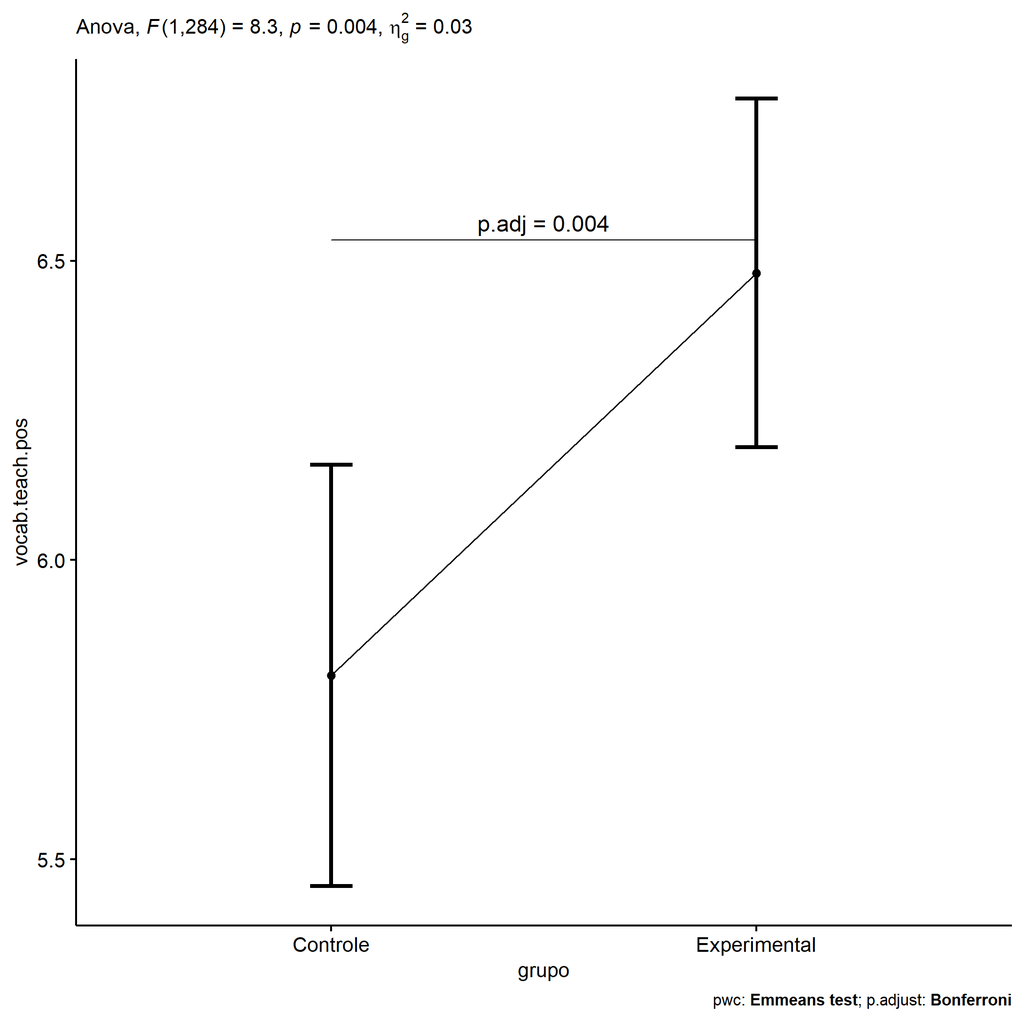

```r
if (!is.null(nrow(plots[["grupo"]]$data)))
  plots[["grupo"]] + ggplot2::scale_color_manual(values = color[["grupo"]])
```

```r
plots <- oneWayAncovaBoxPlots(
  wdat, "vocab.teach.pos", "grupo", aov, pwc, covar = "vocab.teach.pre",
  theme = "classic", color = color[["grupo"]],
  subtitle = which(aov$Effect == "grupo"))
```

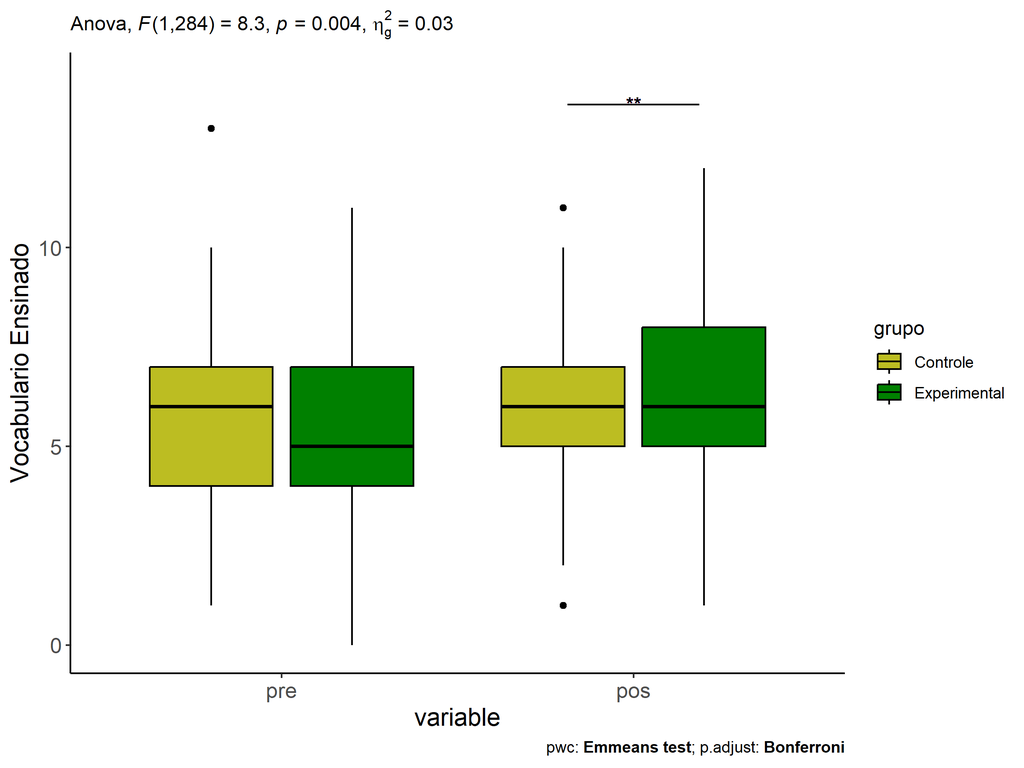

```r
if (length(unique(wdat[["grupo"]])) > 1)
  plots[["grupo"]] + ggplot2::ylab("Vocabulario Ensinado") + ggplot2::scale_x_discrete(labels=c('pre', 'pos'))
```

```r
if (length(unique(wdat.long[["grupo"]])) > 1)
  plots <- oneWayAncovaBoxPlots(
    wdat.long, "vocab.teach", "grupo", aov, pwc.long, pre.post = "time",
    theme = "classic", color = color$prepost)
```

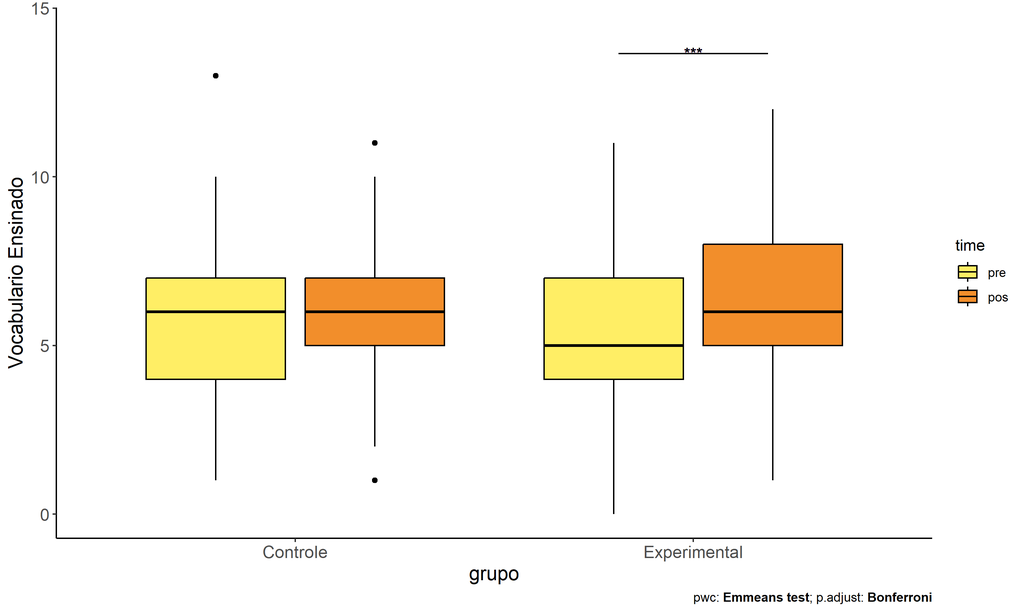

```r
if (length(unique(wdat.long[["grupo"]])) > 1)
  plots[["grupo"]] + ggplot2::ylab("Vocabulario Ensinado")
```

### Checking linearity assumption

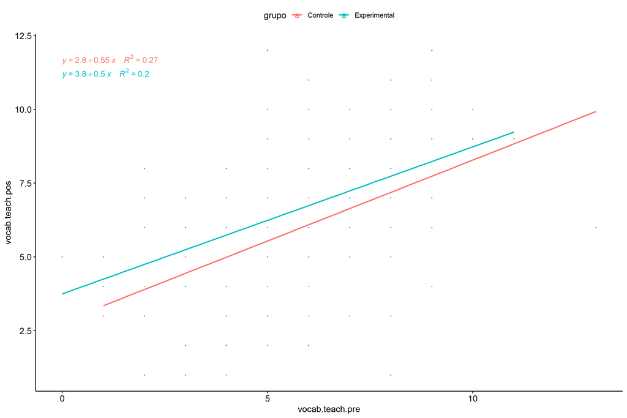

```r
ggscatter(wdat, x = "vocab.teach.pre", y = "vocab.teach.pos", size = 0.5,
          color = "grupo", add = "reg.line")+
  stat_regline_equation(
    aes(label =  paste(..eq.label.., ..rr.label.., sep = "~~~~"), color = grupo)
  )
```

### Checking normality and homogeneity

```r
res <- augment(lm(vocab.teach.pos ~ vocab.teach.pre + grupo, data = wdat))
```

```r
shapiro_test(res$.resid)
```

```
## # A tibble: 1 × 3
##   variable   statistic p.value
##   <chr>          <dbl>   <dbl>
## 1 res$.resid     0.993   0.209
```

```r
levene_test(res, .resid ~ grupo)
```

```
## # A tibble: 1 × 4
##     df1   df2 statistic     p
##   <int> <int>     <dbl> <dbl>
## 1     1   285    0.0293 0.864
```

# ANCOVA and Pairwise for two factors **grupo:Sexo**

## Without remove non-normal data

```r
pdat = remove_group_data(dat[!is.na(dat[["grupo"]]) & !is.na(dat[["Sexo"]]),], "vocab.teach.pos", c("grupo","Sexo"))

pdat.long <- rbind(pdat[,c("id","grupo","Sexo")], pdat[,c("id","grupo","Sexo")])
pdat.long[["time"]] <- c(rep("pre", nrow(pdat)), rep("pos", nrow(pdat)))
pdat.long[["time"]] <- factor(pdat.long[["time"]], c("pre","pos"))
pdat.long[["vocab.teach"]] <- c(pdat[["vocab.teach.pre"]], pdat[["vocab.teach.pos"]])

aov = anova_test(pdat, vocab.teach.pos ~ vocab.teach.pre + grupo*Sexo)
laov[["grupo:Sexo"]] <- get_anova_table(aov)
```

```r
pwcs <- list()
pwcs[["Sexo"]] <- emmeans_test(
  group_by(pdat, grupo), vocab.teach.pos ~ Sexo,
  covariate = vocab.teach.pre, p.adjust.method = "bonferroni")
pwcs[["grupo"]] <- emmeans_test(
  group_by(pdat, Sexo), vocab.teach.pos ~ grupo,
  covariate = vocab.teach.pre, p.adjust.method = "bonferroni")

pwc <- plyr::rbind.fill(pwcs[["grupo"]], pwcs[["Sexo"]])
pwc <- pwc[,c("grupo","Sexo", colnames(pwc)[!colnames(pwc) %in% c("grupo","Sexo")])]
```

```r
pwc.long <- emmeans_test(dplyr::group_by_at(pdat.long, c("grupo","Sexo")),
                         vocab.teach ~ time,
                         p.adjust.method = "bonferroni")
lpwc[["grupo:Sexo"]] <- plyr::rbind.fill(pwc, pwc.long)
```

```r
ds <- get.descriptives(pdat, "vocab.teach.pos", c("grupo","Sexo"), covar = "vocab.teach.pre")
ds <- merge(ds[ds$variable != "vocab.teach.pre",],
            ds[ds$variable == "vocab.teach.pre", !colnames(ds) %in% c("variable")],
            by = c("grupo","Sexo"), all.x = T, suffixes = c("", ".vocab.teach.pre"))
ds <- merge(get_emmeans(pwcs[["grupo"]]), ds, by = c("grupo","Sexo"), suffixes = c(".emms", ""))
ds <- ds[,c("grupo","Sexo","n","mean.vocab.teach.pre","se.vocab.teach.pre","mean","se","emmean","se.emms")]

colnames(ds) <- c("grupo","Sexo", "N", paste0(c("M","SE")," (pre)"),
                  paste0(c("M","SE"), " (unadj)"), paste0(c("M", "SE"), " (adj)"))

lemms[["grupo:Sexo"]] <- ds
```

## Computing ANCOVA and PairWise After removing non-normal data (OK)

```r
wdat = pdat

res = residuals(lm(vocab.teach.pos ~ vocab.teach.pre + grupo*Sexo, data = wdat))
non.normal = getNonNormal(res, wdat$id, plimit = 0.05)

wdat = wdat[!wdat$id %in% non.normal,]

wdat.long <- rbind(wdat[,c("id","grupo","Sexo")], wdat[,c("id","grupo","Sexo")])
wdat.long[["time"]] <- c(rep("pre", nrow(wdat)), rep("pos", nrow(wdat)))
wdat.long[["time"]] <- factor(wdat.long[["time"]], c("pre","pos"))
wdat.long[["vocab.teach"]] <- c(wdat[["vocab.teach.pre"]], wdat[["vocab.teach.pos"]])


ldat[["grupo:Sexo"]] = wdat

(non.normal)
```

```
## [1] "P3709"
```

```r
aov = anova_test(wdat, vocab.teach.pos ~ vocab.teach.pre + grupo*Sexo)
laov[["grupo:Sexo"]] <- merge(get_anova_table(aov), laov[["grupo:Sexo"]], by="Effect", suffixes = c("","'"))

(df = get_anova_table(aov))
```

```
## ANOVA Table (type II tests)
##
##            Effect DFn DFd      F        p p<.05   ges
## 1 vocab.teach.pre   1 283 83.155 1.45e-17     * 0.227
## 2           grupo   1 283  7.022 9.00e-03     * 0.024
## 3            Sexo   1 283  3.821 5.20e-02       0.013
## 4      grupo:Sexo   1 283  1.452 2.29e-01       0.005
```

| Effect | DFn | DFd | F | p | p<.05 | ges |
| --- | --- | --- | --- | --- | --- | --- |
| vocab.teach.pre | 1 | 283 | 83.155 | 0.000 | * | 0.227 |
| grupo | 1 | 283 | 7.022 | 0.009 | * | 0.024 |
| Sexo | 1 | 283 | 3.821 | 0.052 |  | 0.013 |
| grupo:Sexo | 1 | 283 | 1.452 | 0.229 |  | 0.005 |

```r
pwcs <- list()
pwcs[["Sexo"]] <- emmeans_test(
  group_by(wdat, grupo), vocab.teach.pos ~ Sexo,
  covariate = vocab.teach.pre, p.adjust.method = "bonferroni")
pwcs[["grupo"]] <- emmeans_test(
  group_by(wdat, Sexo), vocab.teach.pos ~ grupo,
  covariate = vocab.teach.pre, p.adjust.method = "bonferroni")

pwc <- plyr::rbind.fill(pwcs[["grupo"]], pwcs[["Sexo"]])
pwc <- pwc[,c("grupo","Sexo", colnames(pwc)[!colnames(pwc) %in% c("grupo","Sexo")])]
```

| grupo | Sexo | term | .y. | group1 | group2 | df | statistic | p | p.adj | p.adj.signif |
| --- | --- | --- | --- | --- | --- | --- | --- | --- | --- | --- |
|  | F | vocab.teach.pre*grupo | vocab.teach.pos | Controle | Experimental | 283 | -2.717 | 0.007 | 0.007 | ** |
|  | M | vocab.teach.pre*grupo | vocab.teach.pos | Controle | Experimental | 283 | -1.070 | 0.285 | 0.285 | ns |
| Controle |  | vocab.teach.pre*Sexo | vocab.teach.pos | F | M | 283 | 0.313 | 0.754 | 0.754 | ns |
| Experimental |  | vocab.teach.pre*Sexo | vocab.teach.pos | F | M | 283 | 2.275 | 0.024 | 0.024 | * |

```r
pwc.long <- emmeans_test(dplyr::group_by_at(wdat.long, c("grupo","Sexo")),
                         vocab.teach ~ time,
                         p.adjust.method = "bonferroni")
lpwc[["grupo:Sexo"]] <- merge(plyr::rbind.fill(pwc, pwc.long), lpwc[["grupo:Sexo"]], by=c("grupo","Sexo","term",".y.","group1","group2"), suffixes = c("","'"))
```

| grupo | Sexo | term | .y. | group1 | group2 | df | statistic | p | p.adj | p.adj.signif |
| --- | --- | --- | --- | --- | --- | --- | --- | --- | --- | --- |
| Controle | F | time | vocab.teach | pre | pos | 568 | -0.813 | 0.416 | 0.416 | ns |
| Controle | M | time | vocab.teach | pre | pos | 568 | -0.085 | 0.932 | 0.932 | ns |
| Experimental | F | time | vocab.teach | pre | pos | 568 | -4.445 | 0.000 | 0.000 | **** |
| Experimental | M | time | vocab.teach | pre | pos | 568 | -2.326 | 0.020 | 0.020 | * |

```r
ds <- get.descriptives(wdat, "vocab.teach.pos", c("grupo","Sexo"), covar = "vocab.teach.pre")
ds <- merge(ds[ds$variable != "vocab.teach.pre",],
            ds[ds$variable == "vocab.teach.pre", !colnames(ds) %in% c("variable")],
            by = c("grupo","Sexo"), all.x = T, suffixes = c("", ".vocab.teach.pre"))
ds <- merge(get_emmeans(pwcs[["grupo"]]), ds, by = c("grupo","Sexo"), suffixes = c(".emms", ""))
ds <- ds[,c("grupo","Sexo","n","mean.vocab.teach.pre","se.vocab.teach.pre","mean","se","emmean","se.emms")]

colnames(ds) <- c("grupo","Sexo", "N", paste0(c("M","SE")," (pre)"),
                  paste0(c("M","SE"), " (unadj)"), paste0(c("M", "SE"), " (adj)"))

lemms[["grupo:Sexo"]] <- merge(ds, lemms[["grupo:Sexo"]], by=c("grupo","Sexo"), suffixes = c("","'"))
```

| grupo | Sexo | N | M (pre) | SE (pre) | M (unadj) | SE (unadj) | M (adj) | SE (adj) |
| --- | --- | --- | --- | --- | --- | --- | --- | --- |
| Controle | F | 55 | 5.618 | 0.265 | 5.945 | 0.294 | 5.865 | 0.262 |
| Controle | M | 62 | 6.000 | 0.284 | 6.032 | 0.288 | 5.752 | 0.249 |
| Experimental | F | 86 | 5.221 | 0.204 | 6.651 | 0.234 | 6.779 | 0.210 |
| Experimental | M | 85 | 5.224 | 0.215 | 5.976 | 0.240 | 6.103 | 0.211 |

### Plots for ancova

```r
plots <- twoWayAncovaPlots(
  wdat, "vocab.teach.pos", c("grupo","Sexo"), aov, pwcs, addParam = c("mean_se"),
  font.label.size=10, step.increase=0.05, p.label="p.adj",
  subtitle = which(aov$Effect == "grupo:Sexo"))
```

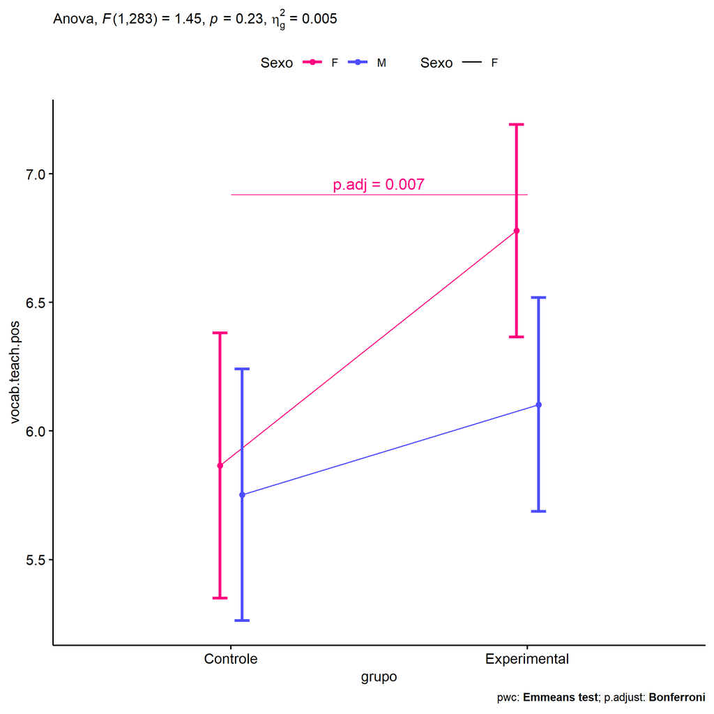

```r
if (!is.null(plots[["grupo"]]))
  plots[["grupo"]] + ggplot2::scale_color_manual(values = color[["Sexo"]])
```

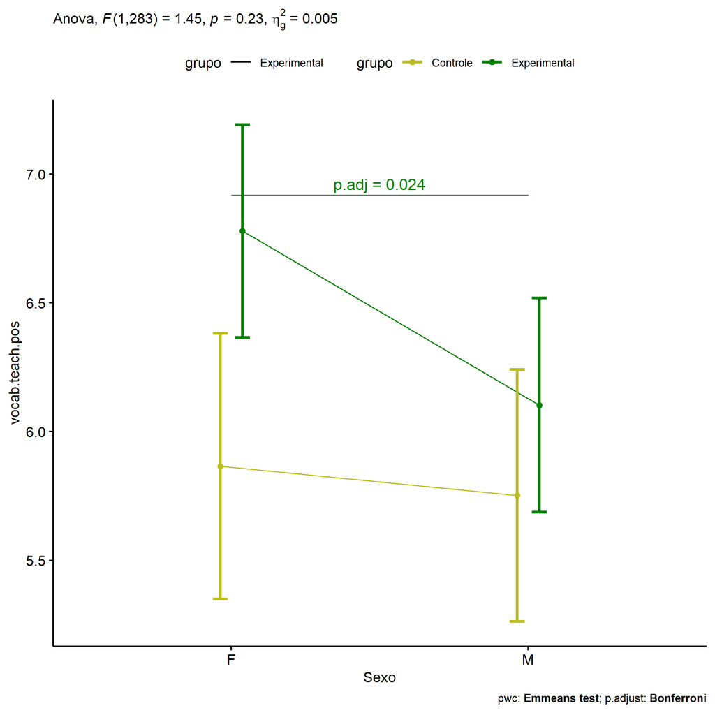

```r
if (!is.null(plots[["Sexo"]]))
  plots[["Sexo"]] + ggplot2::scale_color_manual(values = color[["grupo"]])
```

```r
plots <- twoWayAncovaBoxPlots(
  wdat, "vocab.teach.pos", c("grupo","Sexo"), aov, pwcs, covar = "vocab.teach.pre",
  theme = "classic", color = color[["grupo:Sexo"]],
  subtitle = which(aov$Effect == "grupo:Sexo"))
```

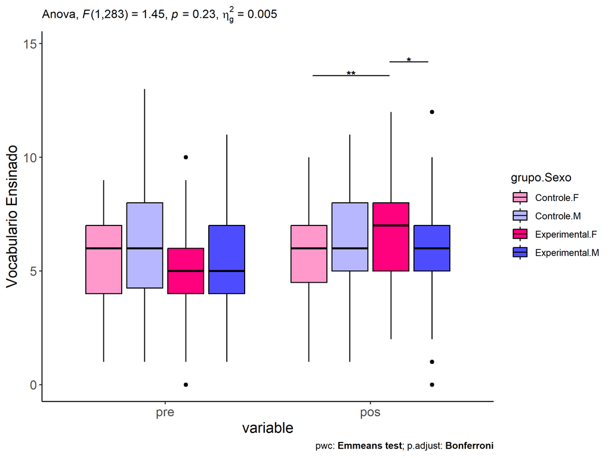

```r
plots[["grupo:Sexo"]] + ggplot2::ylab("Vocabulario Ensinado") + ggplot2::scale_x_discrete(labels=c('pre', 'pos'))
```

```r
plots <- twoWayAncovaBoxPlots(
  wdat.long, "vocab.teach", c("grupo","Sexo"), aov, pwc.long, pre.post = "time",
  theme = "classic", color = color$prepost)
```

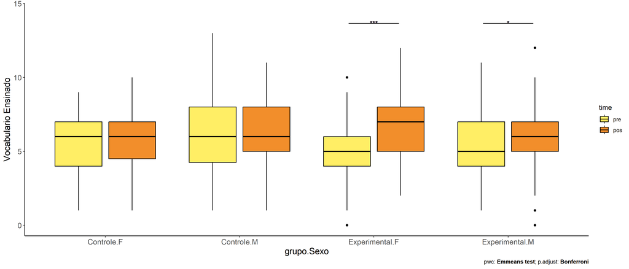

```r
plots[["grupo:Sexo"]] + ggplot2::ylab("Vocabulario Ensinado")
```

### Checking linearity assumption

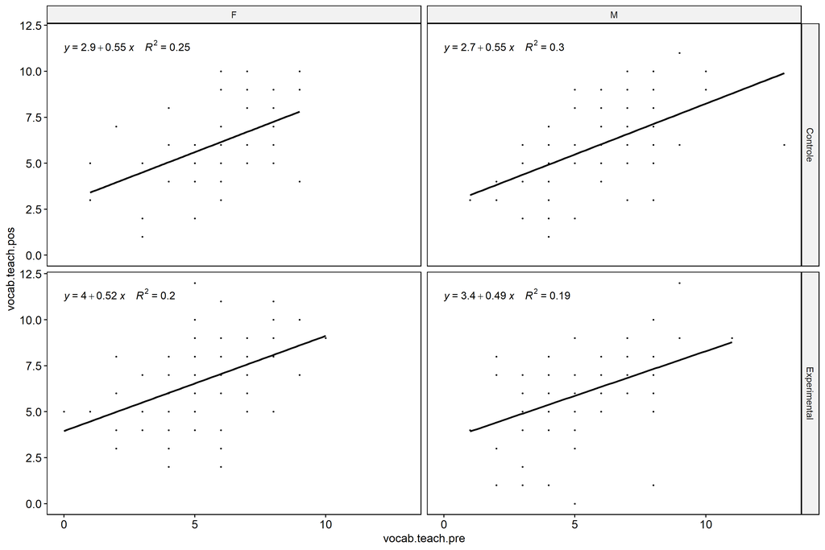

```r
ggscatter(wdat, x = "vocab.teach.pre", y = "vocab.teach.pos", size = 0.5,
          facet.by = c("grupo","Sexo"), add = "reg.line")+
  stat_regline_equation(
    aes(label =  paste(..eq.label.., ..rr.label.., sep = "~~~~"))
  )
```

### Checking normality and homogeneity

```r
res <- augment(lm(vocab.teach.pos ~ vocab.teach.pre + grupo*Sexo, data = wdat))
```

```r
shapiro_test(res$.resid)
```

```
## # A tibble: 1 × 3
##   variable   statistic p.value
##   <chr>          <dbl>   <dbl>
## 1 res$.resid     0.992   0.123
```

```r
levene_test(res, .resid ~ grupo*Sexo)
```

```
## # A tibble: 1 × 4
##     df1   df2 statistic     p
##   <int> <int>     <dbl> <dbl>
## 1     3   284    0.0428 0.988
```

# ANCOVA and Pairwise for two factors **grupo:Zona**

## Without remove non-normal data

```r
pdat = remove_group_data(dat[!is.na(dat[["grupo"]]) & !is.na(dat[["Zona"]]),], "vocab.teach.pos", c("grupo","Zona"))

pdat.long <- rbind(pdat[,c("id","grupo","Zona")], pdat[,c("id","grupo","Zona")])
pdat.long[["time"]] <- c(rep("pre", nrow(pdat)), rep("pos", nrow(pdat)))
pdat.long[["time"]] <- factor(pdat.long[["time"]], c("pre","pos"))
pdat.long[["vocab.teach"]] <- c(pdat[["vocab.teach.pre"]], pdat[["vocab.teach.pos"]])

aov = anova_test(pdat, vocab.teach.pos ~ vocab.teach.pre + grupo*Zona)
laov[["grupo:Zona"]] <- get_anova_table(aov)
```

```r
pwcs <- list()
pwcs[["Zona"]] <- emmeans_test(
  group_by(pdat, grupo), vocab.teach.pos ~ Zona,
  covariate = vocab.teach.pre, p.adjust.method = "bonferroni")
pwcs[["grupo"]] <- emmeans_test(
  group_by(pdat, Zona), vocab.teach.pos ~ grupo,
  covariate = vocab.teach.pre, p.adjust.method = "bonferroni")

pwc <- plyr::rbind.fill(pwcs[["grupo"]], pwcs[["Zona"]])
pwc <- pwc[,c("grupo","Zona", colnames(pwc)[!colnames(pwc) %in% c("grupo","Zona")])]
```

```r
pwc.long <- emmeans_test(dplyr::group_by_at(pdat.long, c("grupo","Zona")),
                         vocab.teach ~ time,
                         p.adjust.method = "bonferroni")
lpwc[["grupo:Zona"]] <- plyr::rbind.fill(pwc, pwc.long)
```

```r
ds <- get.descriptives(pdat, "vocab.teach.pos", c("grupo","Zona"), covar = "vocab.teach.pre")
ds <- merge(ds[ds$variable != "vocab.teach.pre",],
            ds[ds$variable == "vocab.teach.pre", !colnames(ds) %in% c("variable")],
            by = c("grupo","Zona"), all.x = T, suffixes = c("", ".vocab.teach.pre"))
ds <- merge(get_emmeans(pwcs[["grupo"]]), ds, by = c("grupo","Zona"), suffixes = c(".emms", ""))
ds <- ds[,c("grupo","Zona","n","mean.vocab.teach.pre","se.vocab.teach.pre","mean","se","emmean","se.emms")]

colnames(ds) <- c("grupo","Zona", "N", paste0(c("M","SE")," (pre)"),
                  paste0(c("M","SE"), " (unadj)"), paste0(c("M", "SE"), " (adj)"))

lemms[["grupo:Zona"]] <- ds
```

## Computing ANCOVA and PairWise After removing non-normal data (OK)

```r
wdat = pdat

res = residuals(lm(vocab.teach.pos ~ vocab.teach.pre + grupo*Zona, data = wdat))
non.normal = getNonNormal(res, wdat$id, plimit = 0.05)

wdat = wdat[!wdat$id %in% non.normal,]

wdat.long <- rbind(wdat[,c("id","grupo","Zona")], wdat[,c("id","grupo","Zona")])
wdat.long[["time"]] <- c(rep("pre", nrow(wdat)), rep("pos", nrow(wdat)))
wdat.long[["time"]] <- factor(wdat.long[["time"]], c("pre","pos"))
wdat.long[["vocab.teach"]] <- c(wdat[["vocab.teach.pre"]], wdat[["vocab.teach.pos"]])


ldat[["grupo:Zona"]] = wdat

(non.normal)
```

```
## [1] "P3709"
```

```r
aov = anova_test(wdat, vocab.teach.pos ~ vocab.teach.pre + grupo*Zona)
laov[["grupo:Zona"]] <- merge(get_anova_table(aov), laov[["grupo:Zona"]], by="Effect", suffixes = c("","'"))

(df = get_anova_table(aov))
```

```
## ANOVA Table (type II tests)
##
##            Effect DFn DFd      F        p p<.05   ges
## 1 vocab.teach.pre   1 157 67.075 8.54e-14     * 0.299
## 2           grupo   1 157  0.584 4.46e-01       0.004
## 3            Zona   1 157  7.037 9.00e-03     * 0.043
## 4      grupo:Zona   1 157  2.101 1.49e-01       0.013
```

| Effect | DFn | DFd | F | p | p<.05 | ges |
| --- | --- | --- | --- | --- | --- | --- |
| vocab.teach.pre | 1 | 157 | 67.075 | 0.000 | * | 0.299 |
| grupo | 1 | 157 | 0.584 | 0.446 |  | 0.004 |
| Zona | 1 | 157 | 7.037 | 0.009 | * | 0.043 |
| grupo:Zona | 1 | 157 | 2.101 | 0.149 |  | 0.013 |

```r
pwcs <- list()
pwcs[["Zona"]] <- emmeans_test(
  group_by(wdat, grupo), vocab.teach.pos ~ Zona,
  covariate = vocab.teach.pre, p.adjust.method = "bonferroni")
pwcs[["grupo"]] <- emmeans_test(
  group_by(wdat, Zona), vocab.teach.pos ~ grupo,
  covariate = vocab.teach.pre, p.adjust.method = "bonferroni")

pwc <- plyr::rbind.fill(pwcs[["grupo"]], pwcs[["Zona"]])
pwc <- pwc[,c("grupo","Zona", colnames(pwc)[!colnames(pwc) %in% c("grupo","Zona")])]
```

| grupo | Zona | term | .y. | group1 | group2 | df | statistic | p | p.adj | p.adj.signif |
| --- | --- | --- | --- | --- | --- | --- | --- | --- | --- | --- |
|  | Rural | vocab.teach.pre*grupo | vocab.teach.pos | Controle | Experimental | 157 | 0.223 | 0.824 | 0.824 | ns |
|  | Urbana | vocab.teach.pre*grupo | vocab.teach.pos | Controle | Experimental | 157 | -1.621 | 0.107 | 0.107 | ns |
| Controle |  | vocab.teach.pre*Zona | vocab.teach.pos | Rural | Urbana | 157 | 2.710 | 0.007 | 0.007 | ** |
| Experimental |  | vocab.teach.pre*Zona | vocab.teach.pos | Rural | Urbana | 157 | 1.340 | 0.182 | 0.182 | ns |

```r
pwc.long <- emmeans_test(dplyr::group_by_at(wdat.long, c("grupo","Zona")),
                         vocab.teach ~ time,
                         p.adjust.method = "bonferroni")
lpwc[["grupo:Zona"]] <- merge(plyr::rbind.fill(pwc, pwc.long), lpwc[["grupo:Zona"]], by=c("grupo","Zona","term",".y.","group1","group2"), suffixes = c("","'"))
```

| grupo | Zona | term | .y. | group1 | group2 | df | statistic | p | p.adj | p.adj.signif |
| --- | --- | --- | --- | --- | --- | --- | --- | --- | --- | --- |
| Controle | Rural | time | vocab.teach | pre | pos | 316 | -2.318 | 0.021 | 0.021 | * |
| Controle | Urbana | time | vocab.teach | pre | pos | 316 | 0.563 | 0.574 | 0.574 | ns |
| Experimental | Rural | time | vocab.teach | pre | pos | 316 | -3.187 | 0.002 | 0.002 | ** |
| Experimental | Urbana | time | vocab.teach | pre | pos | 316 | -1.560 | 0.120 | 0.120 | ns |

```r
ds <- get.descriptives(wdat, "vocab.teach.pos", c("grupo","Zona"), covar = "vocab.teach.pre")
ds <- merge(ds[ds$variable != "vocab.teach.pre",],
            ds[ds$variable == "vocab.teach.pre", !colnames(ds) %in% c("variable")],
            by = c("grupo","Zona"), all.x = T, suffixes = c("", ".vocab.teach.pre"))
ds <- merge(get_emmeans(pwcs[["grupo"]]), ds, by = c("grupo","Zona"), suffixes = c(".emms", ""))
ds <- ds[,c("grupo","Zona","n","mean.vocab.teach.pre","se.vocab.teach.pre","mean","se","emmean","se.emms")]

colnames(ds) <- c("grupo","Zona", "N", paste0(c("M","SE")," (pre)"),
                  paste0(c("M","SE"), " (unadj)"), paste0(c("M", "SE"), " (adj)"))

lemms[["grupo:Zona"]] <- merge(ds, lemms[["grupo:Zona"]], by=c("grupo","Zona"), suffixes = c("","'"))
```

| grupo | Zona | N | M (pre) | SE (pre) | M (unadj) | SE (unadj) | M (adj) | SE (adj) |
| --- | --- | --- | --- | --- | --- | --- | --- | --- |
| Controle | Rural | 40 | 5.875 | 0.300 | 6.950 | 0.334 | 6.780 | 0.286 |
| Controle | Urbana | 18 | 6.056 | 0.424 | 5.667 | 0.530 | 5.390 | 0.427 |
| Experimental | Rural | 61 | 5.377 | 0.255 | 6.574 | 0.299 | 6.697 | 0.232 |
| Experimental | Urbana | 43 | 5.419 | 0.328 | 6.116 | 0.283 | 6.215 | 0.276 |

### Plots for ancova

```r
plots <- twoWayAncovaPlots(
  wdat, "vocab.teach.pos", c("grupo","Zona"), aov, pwcs, addParam = c("mean_se"),
  font.label.size=10, step.increase=0.05, p.label="p.adj",
  subtitle = which(aov$Effect == "grupo:Zona"))
```

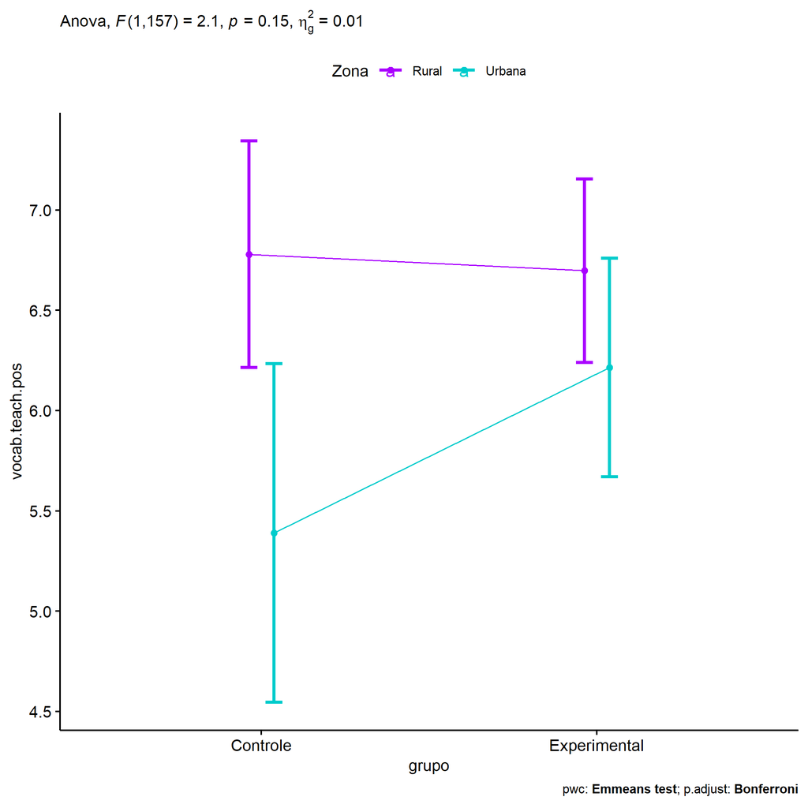

```r
if (!is.null(plots[["grupo"]]))
  plots[["grupo"]] + ggplot2::scale_color_manual(values = color[["Zona"]])
```

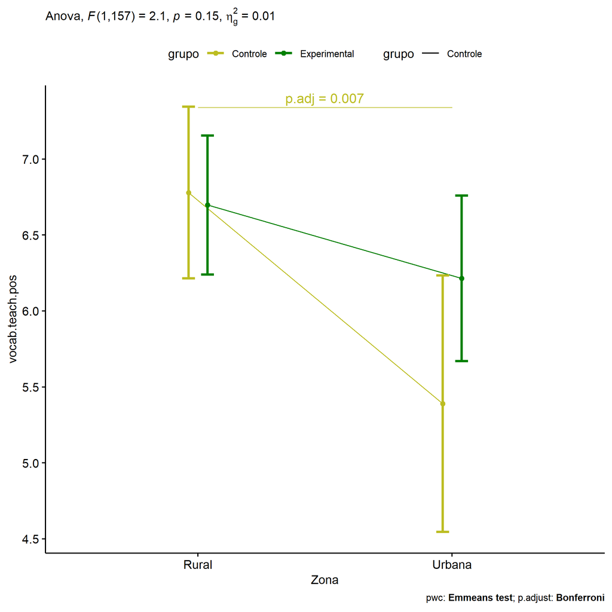

```r
if (!is.null(plots[["Zona"]]))
  plots[["Zona"]] + ggplot2::scale_color_manual(values = color[["grupo"]])
```

```r
plots <- twoWayAncovaBoxPlots(
  wdat, "vocab.teach.pos", c("grupo","Zona"), aov, pwcs, covar = "vocab.teach.pre",
  theme = "classic", color = color[["grupo:Zona"]],
  subtitle = which(aov$Effect == "grupo:Zona"))
```

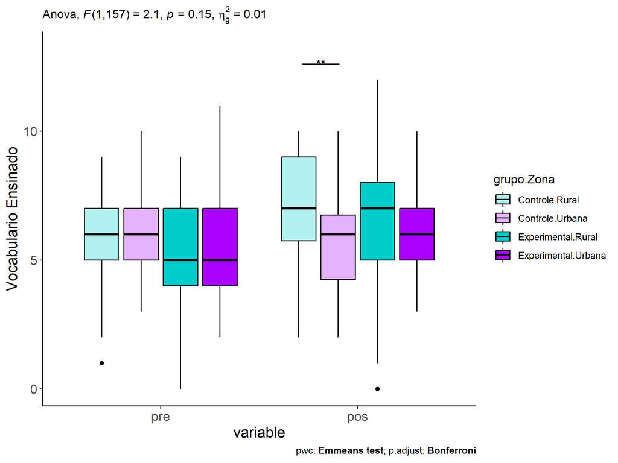

```r
plots[["grupo:Zona"]] + ggplot2::ylab("Vocabulario Ensinado") + ggplot2::scale_x_discrete(labels=c('pre', 'pos'))
```

```r
plots <- twoWayAncovaBoxPlots(
  wdat.long, "vocab.teach", c("grupo","Zona"), aov, pwc.long, pre.post = "time",
  theme = "classic", color = color$prepost)
```

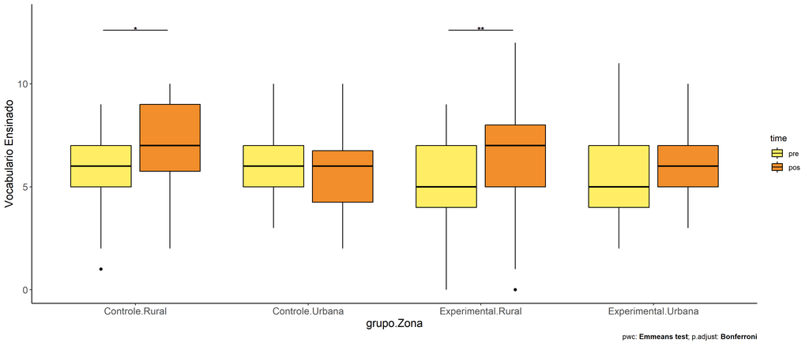

```r
plots[["grupo:Zona"]] + ggplot2::ylab("Vocabulario Ensinado")
```

### Checking linearity assumption

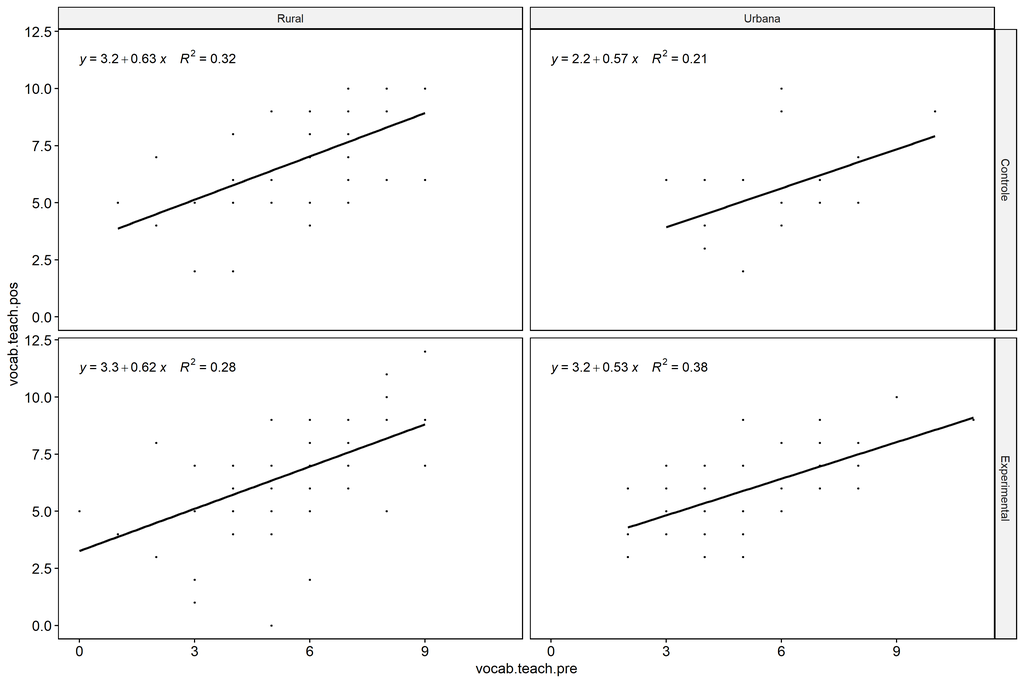

```r
ggscatter(wdat, x = "vocab.teach.pre", y = "vocab.teach.pos", size = 0.5,
          facet.by = c("grupo","Zona"), add = "reg.line")+
  stat_regline_equation(
    aes(label =  paste(..eq.label.., ..rr.label.., sep = "~~~~"))
  )
```

### Checking normality and homogeneity

```r
res <- augment(lm(vocab.teach.pos ~ vocab.teach.pre + grupo*Zona, data = wdat))
```

```r
shapiro_test(res$.resid)
```

```
## # A tibble: 1 × 3
##   variable   statistic p.value
##   <chr>          <dbl>   <dbl>
## 1 res$.resid     0.988   0.170
```

```r
levene_test(res, .resid ~ grupo*Zona)
```

```
## # A tibble: 1 × 4
##     df1   df2 statistic     p
##   <int> <int>     <dbl> <dbl>
## 1     3   158     0.704 0.551
```

# ANCOVA and Pairwise for two factors **grupo:Cor.Raca**

## Without remove non-normal data

```r
pdat = remove_group_data(dat[!is.na(dat[["grupo"]]) & !is.na(dat[["Cor.Raca"]]),], "vocab.teach.pos", c("grupo","Cor.Raca"))

pdat.long <- rbind(pdat[,c("id","grupo","Cor.Raca")], pdat[,c("id","grupo","Cor.Raca")])
pdat.long[["time"]] <- c(rep("pre", nrow(pdat)), rep("pos", nrow(pdat)))
pdat.long[["time"]] <- factor(pdat.long[["time"]], c("pre","pos"))
pdat.long[["vocab.teach"]] <- c(pdat[["vocab.teach.pre"]], pdat[["vocab.teach.pos"]])

aov = anova_test(pdat, vocab.teach.pos ~ vocab.teach.pre + grupo*Cor.Raca)
laov[["grupo:Cor.Raca"]] <- get_anova_table(aov)
```

```r
pwcs <- list()
pwcs[["Cor.Raca"]] <- emmeans_test(
  group_by(pdat, grupo), vocab.teach.pos ~ Cor.Raca,
  covariate = vocab.teach.pre, p.adjust.method = "bonferroni")
pwcs[["grupo"]] <- emmeans_test(
  group_by(pdat, Cor.Raca), vocab.teach.pos ~ grupo,
  covariate = vocab.teach.pre, p.adjust.method = "bonferroni")

pwc <- plyr::rbind.fill(pwcs[["grupo"]], pwcs[["Cor.Raca"]])
pwc <- pwc[,c("grupo","Cor.Raca", colnames(pwc)[!colnames(pwc) %in% c("grupo","Cor.Raca")])]
```

```r
pwc.long <- emmeans_test(dplyr::group_by_at(pdat.long, c("grupo","Cor.Raca")),
                         vocab.teach ~ time,
                         p.adjust.method = "bonferroni")
lpwc[["grupo:Cor.Raca"]] <- plyr::rbind.fill(pwc, pwc.long)
```

```r
ds <- get.descriptives(pdat, "vocab.teach.pos", c("grupo","Cor.Raca"), covar = "vocab.teach.pre")
ds <- merge(ds[ds$variable != "vocab.teach.pre",],
            ds[ds$variable == "vocab.teach.pre", !colnames(ds) %in% c("variable")],
            by = c("grupo","Cor.Raca"), all.x = T, suffixes = c("", ".vocab.teach.pre"))
ds <- merge(get_emmeans(pwcs[["grupo"]]), ds, by = c("grupo","Cor.Raca"), suffixes = c(".emms", ""))
ds <- ds[,c("grupo","Cor.Raca","n","mean.vocab.teach.pre","se.vocab.teach.pre","mean","se","emmean","se.emms")]

colnames(ds) <- c("grupo","Cor.Raca", "N", paste0(c("M","SE")," (pre)"),
                  paste0(c("M","SE"), " (unadj)"), paste0(c("M", "SE"), " (adj)"))

lemms[["grupo:Cor.Raca"]] <- ds
```

## Computing ANCOVA and PairWise After removing non-normal data (OK)

```r
wdat = pdat

res = residuals(lm(vocab.teach.pos ~ vocab.teach.pre + grupo*Cor.Raca, data = wdat))
non.normal = getNonNormal(res, wdat$id, plimit = 0.05)

wdat = wdat[!wdat$id %in% non.normal,]

wdat.long <- rbind(wdat[,c("id","grupo","Cor.Raca")], wdat[,c("id","grupo","Cor.Raca")])
wdat.long[["time"]] <- c(rep("pre", nrow(wdat)), rep("pos", nrow(wdat)))
wdat.long[["time"]] <- factor(wdat.long[["time"]], c("pre","pos"))
wdat.long[["vocab.teach"]] <- c(wdat[["vocab.teach.pre"]], wdat[["vocab.teach.pos"]])


ldat[["grupo:Cor.Raca"]] = wdat

(non.normal)
```

[output not shown]

```r
aov = anova_test(wdat, vocab.teach.pos ~ vocab.teach.pre + grupo*Cor.Raca)
laov[["grupo:Cor.Raca"]] <- merge(get_anova_table(aov), laov[["grupo:Cor.Raca"]], by="Effect", suffixes = c("","'"))

(df = get_anova_table(aov))
```

```
## ANOVA Table (type II tests)
##
##            Effect DFn DFd      F        p p<.05   ges
## 1 vocab.teach.pre   1 111 32.732 9.09e-08     * 0.228
## 2           grupo   1 111  1.576 2.12e-01       0.014
## 3        Cor.Raca   1 111  3.283 7.30e-02       0.029
## 4  grupo:Cor.Raca   1 111  0.877 3.51e-01       0.008
```

| Effect | DFn | DFd | F | p | p<.05 | ges |
| --- | --- | --- | --- | --- | --- | --- |
| vocab.teach.pre | 1 | 111 | 32.732 | 0.000 | * | 0.228 |
| grupo | 1 | 111 | 1.576 | 0.212 |  | 0.014 |
| Cor.Raca | 1 | 111 | 3.283 | 0.073 |  | 0.029 |
| grupo:Cor.Raca | 1 | 111 | 0.877 | 0.351 |  | 0.008 |

```r
pwcs <- list()
pwcs[["Cor.Raca"]] <- emmeans_test(
  group_by(wdat, grupo), vocab.teach.pos ~ Cor.Raca,
  covariate = vocab.teach.pre, p.adjust.method = "bonferroni")
pwcs[["grupo"]] <- emmeans_test(
  group_by(wdat, Cor.Raca), vocab.teach.pos ~ grupo,
  covariate = vocab.teach.pre, p.adjust.method = "bonferroni")

pwc <- plyr::rbind.fill(pwcs[["grupo"]], pwcs[["Cor.Raca"]])
pwc <- pwc[,c("grupo","Cor.Raca", colnames(pwc)[!colnames(pwc) %in% c("grupo","Cor.Raca")])]
```

| grupo | Cor.Raca | term | .y. | group1 | group2 | df | statistic | p | p.adj | p.adj.signif |
| --- | --- | --- | --- | --- | --- | --- | --- | --- | --- | --- |
|  | Branca | vocab.teach.pre*grupo | vocab.teach.pos | Controle | Experimental | 111 | 0.353 | 0.725 | 0.725 | ns |
|  | Parda | vocab.teach.pre*grupo | vocab.teach.pos | Controle | Experimental | 111 | -1.523 | 0.131 | 0.131 | ns |
| Controle |  | vocab.teach.pre*Cor.Raca | vocab.teach.pos | Branca | Parda | 111 | 1.847 | 0.067 | 0.067 | ns |
| Experimental |  | vocab.teach.pre*Cor.Raca | vocab.teach.pos | Branca | Parda | 111 | 0.892 | 0.374 | 0.374 | ns |

```r
pwc.long <- emmeans_test(dplyr::group_by_at(wdat.long, c("grupo","Cor.Raca")),
                         vocab.teach ~ time,
                         p.adjust.method = "bonferroni")
lpwc[["grupo:Cor.Raca"]] <- merge(plyr::rbind.fill(pwc, pwc.long), lpwc[["grupo:Cor.Raca"]], by=c("grupo","Cor.Raca","term",".y.","group1","group2"), suffixes = c("","'"))
```

| grupo | Cor.Raca | term | .y. | group1 | group2 | df | statistic | p | p.adj | p.adj.signif |
| --- | --- | --- | --- | --- | --- | --- | --- | --- | --- | --- |
| Controle | Branca | time | vocab.teach | pre | pos | 224 | -1.172 | 0.243 | 0.243 | ns |
| Controle | Parda | time | vocab.teach | pre | pos | 224 | -0.841 | 0.401 | 0.401 | ns |
| Experimental | Branca | time | vocab.teach | pre | pos | 224 | -1.633 | 0.104 | 0.104 | ns |
| Experimental | Parda | time | vocab.teach | pre | pos | 224 | -2.837 | 0.005 | 0.005 | ** |

```r
ds <- get.descriptives(wdat, "vocab.teach.pos", c("grupo","Cor.Raca"), covar = "vocab.teach.pre")
ds <- merge(ds[ds$variable != "vocab.teach.pre",],
            ds[ds$variable == "vocab.teach.pre", !colnames(ds) %in% c("variable")],
            by = c("grupo","Cor.Raca"), all.x = T, suffixes = c("", ".vocab.teach.pre"))
ds <- merge(get_emmeans(pwcs[["grupo"]]), ds, by = c("grupo","Cor.Raca"), suffixes = c(".emms", ""))
ds <- ds[,c("grupo","Cor.Raca","n","mean.vocab.teach.pre","se.vocab.teach.pre","mean","se","emmean","se.emms")]

colnames(ds) <- c("grupo","Cor.Raca", "N", paste0(c("M","SE")," (pre)"),
                  paste0(c("M","SE"), " (unadj)"), paste0(c("M", "SE"), " (adj)"))

lemms[["grupo:Cor.Raca"]] <- merge(ds, lemms[["grupo:Cor.Raca"]], by=c("grupo","Cor.Raca"), suffixes = c("","'"))
```

| grupo | Cor.Raca | N | M (pre) | SE (pre) | M (unadj) | SE (unadj) | M (adj) | SE (adj) |
| --- | --- | --- | --- | --- | --- | --- | --- | --- |
| Controle | Branca | 7 | 6.571 | 0.481 | 8.000 | 0.690 | 7.331 | 0.804 |
| Controle | Parda | 44 | 5.364 | 0.361 | 5.773 | 0.333 | 5.736 | 0.317 |
| Experimental | Branca | 13 | 5.769 | 0.482 | 7.231 | 0.533 | 6.982 | 0.585 |
| Experimental | Parda | 52 | 4.942 | 0.299 | 6.212 | 0.370 | 6.395 | 0.294 |

### Plots for ancova

```r
plots <- twoWayAncovaPlots(
  wdat, "vocab.teach.pos", c("grupo","Cor.Raca"), aov, pwcs, addParam = c("mean_se"),
  font.label.size=10, step.increase=0.05, p.label="p.adj",
  subtitle = which(aov$Effect == "grupo:Cor.Raca"))
```

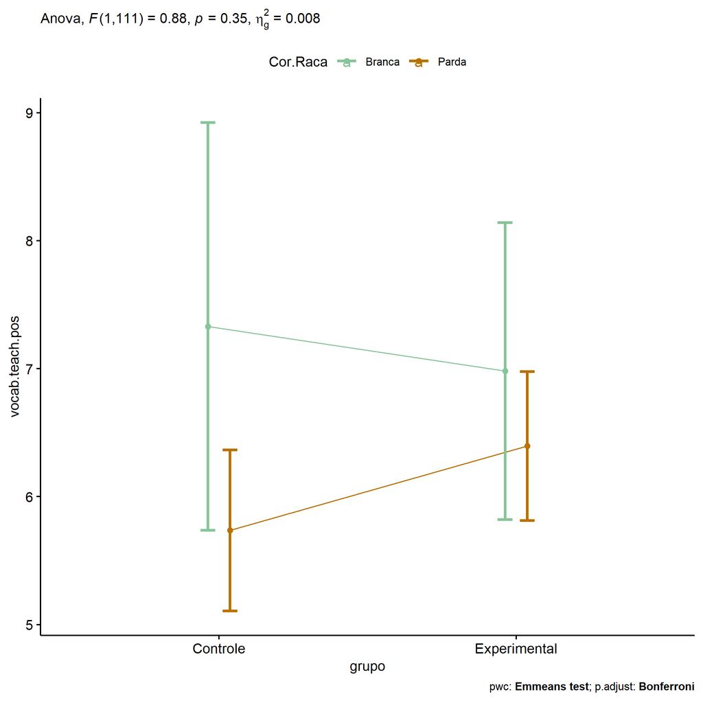

```r
if (!is.null(plots[["grupo"]]))
  plots[["grupo"]] + ggplot2::scale_color_manual(values = color[["Cor.Raca"]])
```

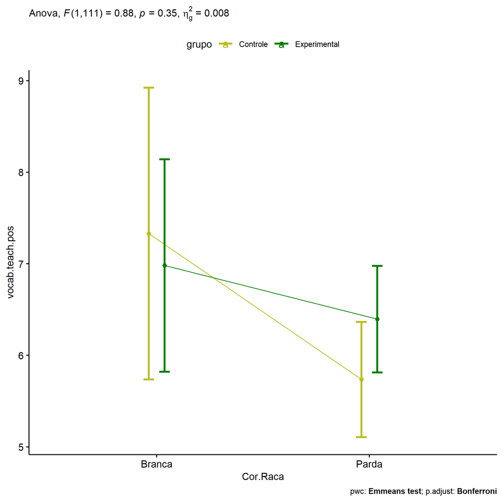

```r
if (!is.null(plots[["Cor.Raca"]]))
  plots[["Cor.Raca"]] + ggplot2::scale_color_manual(values = color[["grupo"]])
```

```r
plots <- twoWayAncovaBoxPlots(
  wdat, "vocab.teach.pos", c("grupo","Cor.Raca"), aov, pwcs, covar = "vocab.teach.pre",
  theme = "classic", color = color[["grupo:Cor.Raca"]],
  subtitle = which(aov$Effect == "grupo:Cor.Raca"))
```

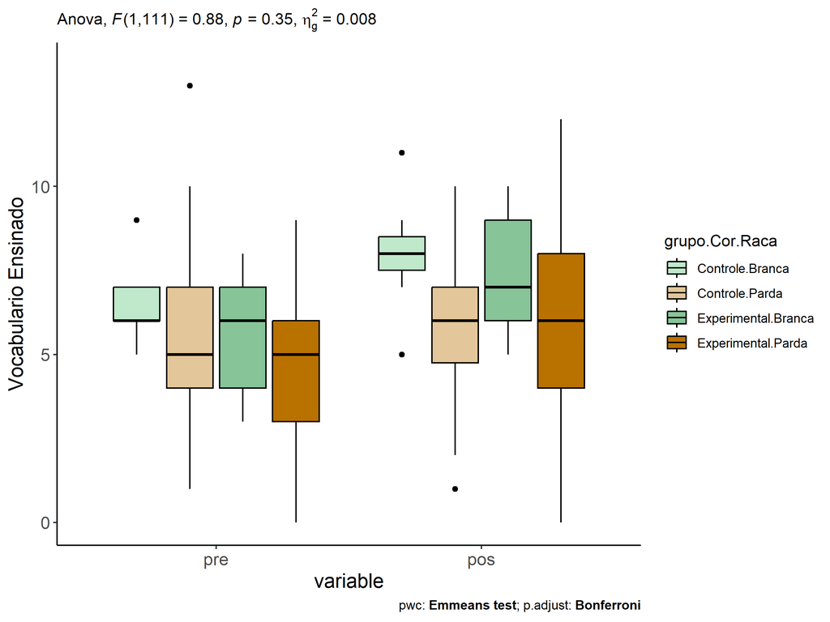

```r
plots[["grupo:Cor.Raca"]] + ggplot2::ylab("Vocabulario Ensinado") + ggplot2::scale_x_discrete(labels=c('pre', 'pos'))
```

```r
plots <- twoWayAncovaBoxPlots(
  wdat.long, "vocab.teach", c("grupo","Cor.Raca"), aov, pwc.long, pre.post = "time",
  theme = "classic", color = color$prepost)
```

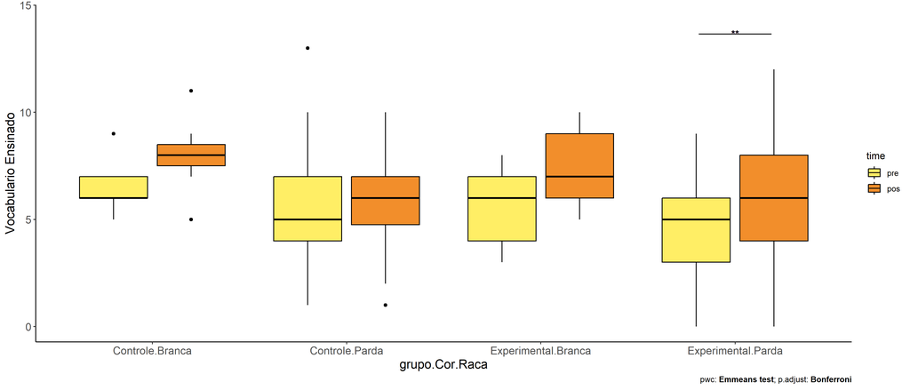

```r
plots[["grupo:Cor.Raca"]] + ggplot2::ylab("Vocabulario Ensinado")
```

### Checking linearity assumption

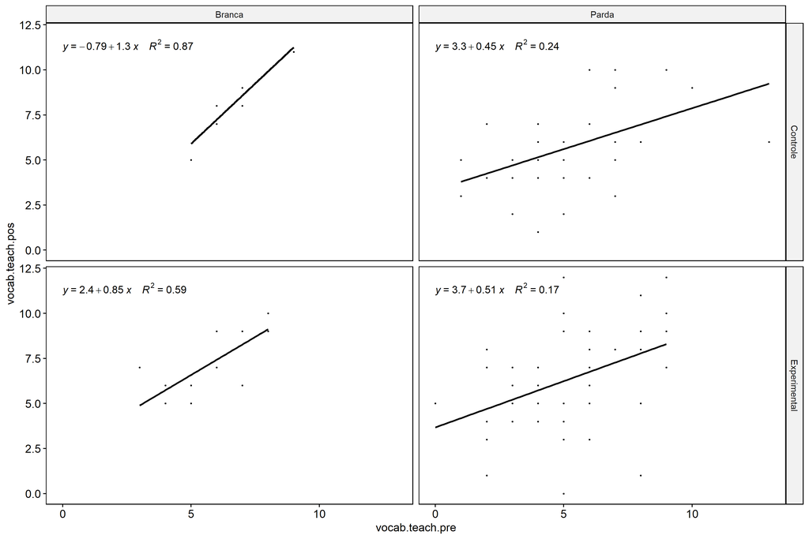

```r
ggscatter(wdat, x = "vocab.teach.pre", y = "vocab.teach.pos", size = 0.5,
          facet.by = c("grupo","Cor.Raca"), add = "reg.line")+
  stat_regline_equation(
    aes(label =  paste(..eq.label.., ..rr.label.., sep = "~~~~"))
  )
```

### Checking normality and homogeneity

```r
res <- augment(lm(vocab.teach.pos ~ vocab.teach.pre + grupo*Cor.Raca, data = wdat))
```

```r
shapiro_test(res$.resid)
```

```
## # A tibble: 1 × 3
##   variable   statistic p.value
##   <chr>          <dbl>   <dbl>
## 1 res$.resid     0.985   0.212
```

```r
levene_test(res, .resid ~ grupo*Cor.Raca)
```

```
## # A tibble: 1 × 4
##     df1   df2 statistic      p
##   <int> <int>     <dbl>  <dbl>
## 1     3   112      2.13 0.0999
```

# ANCOVA and Pairwise for two factors **grupo:vocab.teach.quintile**

## Without remove non-normal data

```r
pdat = remove_group_data(dat[!is.na(dat[["grupo"]]) & !is.na(dat[["vocab.teach.quintile"]]),], "vocab.teach.pos", c("grupo","vocab.teach.quintile"))

pdat.long <- rbind(pdat[,c("id","grupo","vocab.teach.quintile")], pdat[,c("id","grupo","vocab.teach.quintile")])
pdat.long[["time"]] <- c(rep("pre", nrow(pdat)), rep("pos", nrow(pdat)))
pdat.long[["time"]] <- factor(pdat.long[["time"]], c("pre","pos"))
pdat.long[["vocab.teach"]] <- c(pdat[["vocab.teach.pre"]], pdat[["vocab.teach.pos"]])

aov = anova_test(pdat, vocab.teach.pos ~ vocab.teach.pre + grupo*vocab.teach.quintile)
laov[["grupo:vocab.teach.quintile"]] <- get_anova_table(aov)
```

```r
pwcs <- list()
pwcs[["vocab.teach.quintile"]] <- emmeans_test(
  group_by(pdat, grupo), vocab.teach.pos ~ vocab.teach.quintile,
  covariate = vocab.teach.pre, p.adjust.method = "bonferroni")
pwcs[["grupo"]] <- emmeans_test(
  group_by(pdat, vocab.teach.quintile), vocab.teach.pos ~ grupo,
  covariate = vocab.teach.pre, p.adjust.method = "bonferroni")

pwc <- plyr::rbind.fill(pwcs[["grupo"]], pwcs[["vocab.teach.quintile"]])
pwc <- pwc[,c("grupo","vocab.teach.quintile", colnames(pwc)[!colnames(pwc) %in% c("grupo","vocab.teach.quintile")])]
```

```r
pwc.long <- emmeans_test(dplyr::group_by_at(pdat.long, c("grupo","vocab.teach.quintile")),
                         vocab.teach ~ time,
                         p.adjust.method = "bonferroni")
lpwc[["grupo:vocab.teach.quintile"]] <- plyr::rbind.fill(pwc, pwc.long)
```

```r
ds <- get.descriptives(pdat, "vocab.teach.pos", c("grupo","vocab.teach.quintile"), covar = "vocab.teach.pre")
ds <- merge(ds[ds$variable != "vocab.teach.pre",],
            ds[ds$variable == "vocab.teach.pre", !colnames(ds) %in% c("variable")],
            by = c("grupo","vocab.teach.quintile"), all.x = T, suffixes = c("", ".vocab.teach.pre"))
ds <- merge(get_emmeans(pwcs[["grupo"]]), ds, by = c("grupo","vocab.teach.quintile"), suffixes = c(".emms", ""))
ds <- ds[,c("grupo","vocab.teach.quintile","n","mean.vocab.teach.pre","se.vocab.teach.pre","mean","se","emmean","se.emms")]

colnames(ds) <- c("grupo","vocab.teach.quintile", "N", paste0(c("M","SE")," (pre)"),
                  paste0(c("M","SE"), " (unadj)"), paste0(c("M", "SE"), " (adj)"))

lemms[["grupo:vocab.teach.quintile"]] <- ds
```

## Computing ANCOVA and PairWise After removing non-normal data (OK)

```r
wdat = pdat

res = residuals(lm(vocab.teach.pos ~ vocab.teach.pre + grupo*vocab.teach.quintile, data = wdat))
non.normal = getNonNormal(res, wdat$id, plimit = 0.05)

wdat = wdat[!wdat$id %in% non.normal,]

wdat.long <- rbind(wdat[,c("id","grupo","vocab.teach.quintile")], wdat[,c("id","grupo","vocab.teach.quintile")])
wdat.long[["time"]] <- c(rep("pre", nrow(wdat)), rep("pos", nrow(wdat)))
wdat.long[["time"]] <- factor(wdat.long[["time"]], c("pre","pos"))
wdat.long[["vocab.teach"]] <- c(wdat[["vocab.teach.pre"]], wdat[["vocab.teach.pos"]])


ldat[["grupo:vocab.teach.quintile"]] = wdat

(non.normal)
```

```
## [1] "P3709"
```

```r
aov = anova_test(wdat, vocab.teach.pos ~ vocab.teach.pre + grupo*vocab.teach.quintile)
laov[["grupo:vocab.teach.quintile"]] <- merge(get_anova_table(aov), laov[["grupo:vocab.teach.quintile"]], by="Effect", suffixes = c("","'"))

(df = get_anova_table(aov))
```

```
## ANOVA Table (type II tests)
##
##                       Effect DFn DFd     F     p p<.05   ges
## 1            vocab.teach.pre   1 277 3.847 0.051       0.014
## 2                      grupo   1 277 7.417 0.007     * 0.026
## 3       vocab.teach.quintile   4 277 0.681 0.606       0.010
## 4 grupo:vocab.teach.quintile   4 277 0.530 0.714       0.008
```

| Effect | DFn | DFd | F | p | p<.05 | ges |
| --- | --- | --- | --- | --- | --- | --- |
| vocab.teach.pre | 1 | 277 | 3.847 | 0.051 |  | 0.014 |
| grupo | 1 | 277 | 7.417 | 0.007 | * | 0.026 |
| vocab.teach.quintile | 4 | 277 | 0.681 | 0.606 |  | 0.010 |
| grupo:vocab.teach.quintile | 4 | 277 | 0.530 | 0.714 |  | 0.008 |

```r
pwcs <- list()
pwcs[["vocab.teach.quintile"]] <- emmeans_test(
  group_by(wdat, grupo), vocab.teach.pos ~ vocab.teach.quintile,
  covariate = vocab.teach.pre, p.adjust.method = "bonferroni")
pwcs[["grupo"]] <- emmeans_test(
  group_by(wdat, vocab.teach.quintile), vocab.teach.pos ~ grupo,
  covariate = vocab.teach.pre, p.adjust.method = "bonferroni")

pwc <- plyr::rbind.fill(pwcs[["grupo"]], pwcs[["vocab.teach.quintile"]])
pwc <- pwc[,c("grupo","vocab.teach.quintile", colnames(pwc)[!colnames(pwc) %in% c("grupo","vocab.teach.quintile")])]
```

| grupo | vocab.teach.quintile | term | .y. | group1 | group2 | df | statistic | p | p.adj | p.adj.signif |
| --- | --- | --- | --- | --- | --- | --- | --- | --- | --- | --- |
|  | 1st quintile | vocab.teach.pre*grupo | vocab.teach.pos | Controle | Experimental | 277 | -0.933 | 0.352 | 0.352 | ns |
|  | 2nd quintile | vocab.teach.pre*grupo | vocab.teach.pos | Controle | Experimental | 277 | -1.720 | 0.086 | 0.086 | ns |
|  | 3rd quintile | vocab.teach.pre*grupo | vocab.teach.pos | Controle | Experimental | 277 | -1.967 | 0.050 | 0.050 | ns |
|  | 4th quintile | vocab.teach.pre*grupo | vocab.teach.pos | Controle | Experimental | 277 | -0.144 | 0.886 | 0.886 | ns |
|  | 5th quintile | vocab.teach.pre*grupo | vocab.teach.pos | Controle | Experimental | 277 | -1.354 | 0.177 | 0.177 | ns |
| Controle |  | vocab.teach.pre*vocab.teach.quintile | vocab.teach.pos | 1st quintile | 2nd quintile | 277 | 0.495 | 0.621 | 1.000 | ns |
| Controle |  | vocab.teach.pre*vocab.teach.quintile | vocab.teach.pos | 1st quintile | 3rd quintile | 277 | 0.000 | 1.000 | 1.000 | ns |
| Controle |  | vocab.teach.pre*vocab.teach.quintile | vocab.teach.pos | 1st quintile | 4th quintile | 277 | -0.684 | 0.495 | 1.000 | ns |
| Controle |  | vocab.teach.pre*vocab.teach.quintile | vocab.teach.pos | 1st quintile | 5th quintile | 277 | -0.758 | 0.449 | 1.000 | ns |
| Controle |  | vocab.teach.pre*vocab.teach.quintile | vocab.teach.pos | 2nd quintile | 3rd quintile | 277 | -0.648 | 0.518 | 1.000 | ns |
| Controle |  | vocab.teach.pre*vocab.teach.quintile | vocab.teach.pos | 2nd quintile | 4th quintile | 277 | -1.412 | 0.159 | 1.000 | ns |
| Controle |  | vocab.teach.pre*vocab.teach.quintile | vocab.teach.pos | 2nd quintile | 5th quintile | 277 | -1.387 | 0.167 | 1.000 | ns |
| Controle |  | vocab.teach.pre*vocab.teach.quintile | vocab.teach.pos | 3rd quintile | 4th quintile | 277 | -1.336 | 0.183 | 1.000 | ns |
| Controle |  | vocab.teach.pre*vocab.teach.quintile | vocab.teach.pos | 3rd quintile | 5th quintile | 277 | -1.384 | 0.167 | 1.000 | ns |
| Controle |  | vocab.teach.pre*vocab.teach.quintile | vocab.teach.pos | 4th quintile | 5th quintile | 277 | -0.435 | 0.664 | 1.000 | ns |
| Experimental |  | vocab.teach.pre*vocab.teach.quintile | vocab.teach.pos | 1st quintile | 2nd quintile | 277 | 0.061 | 0.951 | 1.000 | ns |
| Experimental |  | vocab.teach.pre*vocab.teach.quintile | vocab.teach.pos | 1st quintile | 3rd quintile | 277 | 0.066 | 0.947 | 1.000 | ns |
| Experimental |  | vocab.teach.pre*vocab.teach.quintile | vocab.teach.pos | 1st quintile | 4th quintile | 277 | 0.021 | 0.984 | 1.000 | ns |
| Experimental |  | vocab.teach.pre*vocab.teach.quintile | vocab.teach.pos | 1st quintile | 5th quintile | 277 | -0.573 | 0.567 | 1.000 | ns |
| Experimental |  | vocab.teach.pre*vocab.teach.quintile | vocab.teach.pos | 2nd quintile | 3rd quintile | 277 | 0.009 | 0.993 | 1.000 | ns |
| Experimental |  | vocab.teach.pre*vocab.teach.quintile | vocab.teach.pos | 2nd quintile | 4th quintile | 277 | -0.033 | 0.974 | 1.000 | ns |
| Experimental |  | vocab.teach.pre*vocab.teach.quintile | vocab.teach.pos | 2nd quintile | 5th quintile | 277 | -0.773 | 0.440 | 1.000 | ns |
| Experimental |  | vocab.teach.pre*vocab.teach.quintile | vocab.teach.pos | 3rd quintile | 4th quintile | 277 | -0.060 | 0.952 | 1.000 | ns |
| Experimental |  | vocab.teach.pre*vocab.teach.quintile | vocab.teach.pos | 3rd quintile | 5th quintile | 277 | -1.130 | 0.260 | 1.000 | ns |
| Experimental |  | vocab.teach.pre*vocab.teach.quintile | vocab.teach.pos | 4th quintile | 5th quintile | 277 | -1.294 | 0.197 | 1.000 | ns |

```r
pwc.long <- emmeans_test(dplyr::group_by_at(wdat.long, c("grupo","vocab.teach.quintile")),
                         vocab.teach ~ time,
                         p.adjust.method = "bonferroni")
lpwc[["grupo:vocab.teach.quintile"]] <- merge(plyr::rbind.fill(pwc, pwc.long), lpwc[["grupo:vocab.teach.quintile"]], by=c("grupo","vocab.teach.quintile","term",".y.","group1","group2"), suffixes = c("","'"))
```

| grupo | vocab.teach.quintile | term | .y. | group1 | group2 | df | statistic | p | p.adj | p.adj.signif |
| --- | --- | --- | --- | --- | --- | --- | --- | --- | --- | --- |
| Controle | 1st quintile | time | vocab.teach | pre | pos | 556 | -3.082 | 0.002 | 0.002 | ** |
| Controle | 2nd quintile | time | vocab.teach | pre | pos | 556 | -1.517 | 0.130 | 0.130 | ns |
| Controle | 3rd quintile | time | vocab.teach | pre | pos | 556 | -1.292 | 0.197 | 0.197 | ns |
| Controle | 4th quintile | time | vocab.teach | pre | pos | 556 | -0.768 | 0.443 | 0.443 | ns |
| Controle | 5th quintile | time | vocab.teach | pre | pos | 556 | 2.170 | 0.030 | 0.030 | * |
| Experimental | 1st quintile | time | vocab.teach | pre | pos | 556 | -5.207 | 0.000 | 0.000 | **** |
| Experimental | 2nd quintile | time | vocab.teach | pre | pos | 556 | -4.749 | 0.000 | 0.000 | **** |
| Experimental | 3rd quintile | time | vocab.teach | pre | pos | 556 | -5.579 | 0.000 | 0.000 | **** |
| Experimental | 4th quintile | time | vocab.teach | pre | pos | 556 | -0.959 | 0.338 | 0.338 | ns |
| Experimental | 5th quintile | time | vocab.teach | pre | pos | 556 | -0.071 | 0.944 | 0.944 | ns |

```r
ds <- get.descriptives(wdat, "vocab.teach.pos", c("grupo","vocab.teach.quintile"), covar = "vocab.teach.pre")
ds <- merge(ds[ds$variable != "vocab.teach.pre",],
            ds[ds$variable == "vocab.teach.pre", !colnames(ds) %in% c("variable")],
            by = c("grupo","vocab.teach.quintile"), all.x = T, suffixes = c("", ".vocab.teach.pre"))
ds <- merge(get_emmeans(pwcs[["grupo"]]), ds, by = c("grupo","vocab.teach.quintile"), suffixes = c(".emms", ""))
ds <- ds[,c("grupo","vocab.teach.quintile","n","mean.vocab.teach.pre","se.vocab.teach.pre","mean","se","emmean","se.emms")]

colnames(ds) <- c("grupo","vocab.teach.quintile", "N", paste0(c("M","SE")," (pre)"),
                  paste0(c("M","SE"), " (unadj)"), paste0(c("M", "SE"), " (adj)"))

lemms[["grupo:vocab.teach.quintile"]] <- merge(ds, lemms[["grupo:vocab.teach.quintile"]], by=c("grupo","vocab.teach.quintile"), suffixes = c("","'"))
```

| grupo | vocab.teach.quintile | N | M (pre) | SE (pre) | M (unadj) | SE (unadj) | M (adj) | SE (adj) |
| --- | --- | --- | --- | --- | --- | --- | --- | --- |
| Controle | 1st quintile | 7 | 1.571 | 0.202 | 4.000 | 0.577 | 5.350 | 1.012 |
| Controle | 2nd quintile | 10 | 3.000 | 0.000 | 4.000 | 0.537 | 4.855 | 0.759 |
| Controle | 3rd quintile | 31 | 4.548 | 0.091 | 5.032 | 0.329 | 5.350 | 0.388 |
| Controle | 4th quintile | 25 | 6.000 | 0.000 | 6.320 | 0.373 | 6.135 | 0.404 |
| Controle | 5th quintile | 44 | 7.932 | 0.173 | 7.250 | 0.307 | 6.395 | 0.527 |
| Experimental | 1st quintile | 11 | 1.636 | 0.203 | 4.909 | 0.667 | 6.236 | 0.899 |
| Experimental | 2nd quintile | 18 | 3.000 | 0.000 | 5.333 | 0.443 | 6.188 | 0.636 |
| Experimental | 3rd quintile | 71 | 4.451 | 0.059 | 5.831 | 0.242 | 6.183 | 0.294 |
| Experimental | 4th quintile | 25 | 6.000 | 0.000 | 6.400 | 0.440 | 6.215 | 0.404 |
| Experimental | 5th quintile | 46 | 7.717 | 0.131 | 7.739 | 0.282 | 6.958 | 0.492 |

### Plots for ancova

```r
plots <- twoWayAncovaPlots(
  wdat, "vocab.teach.pos", c("grupo","vocab.teach.quintile"), aov, pwcs, addParam = c("mean_se"),
  font.label.size=10, step.increase=0.05, p.label="p.adj",
  subtitle = which(aov$Effect == "grupo:vocab.teach.quintile"))
```

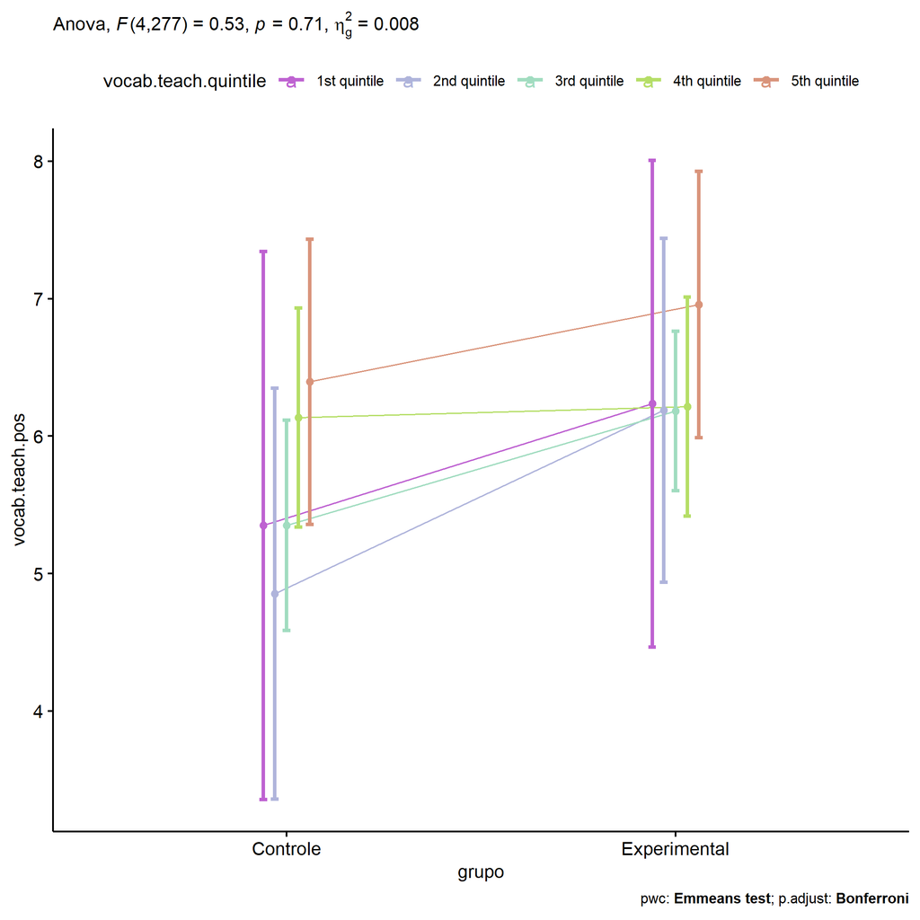

```r
if (!is.null(plots[["grupo"]]))
  plots[["grupo"]] + ggplot2::scale_color_manual(values = color[["vocab.teach.quintile"]])
```

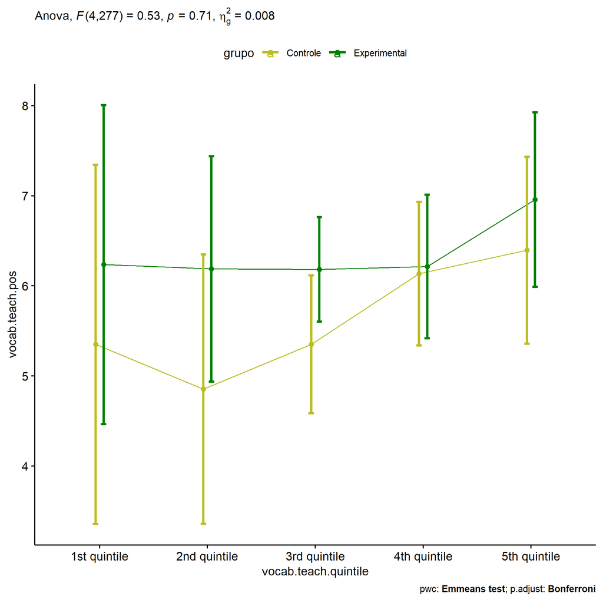

```r
if (!is.null(plots[["vocab.teach.quintile"]]))
  plots[["vocab.teach.quintile"]] + ggplot2::scale_color_manual(values = color[["grupo"]])
```

```r
plots <- twoWayAncovaBoxPlots(
  wdat, "vocab.teach.pos", c("grupo","vocab.teach.quintile"), aov, pwcs, covar = "vocab.teach.pre",
  theme = "classic", color = color[["grupo:vocab.teach.quintile"]],
  subtitle = which(aov$Effect == "grupo:vocab.teach.quintile"))
```

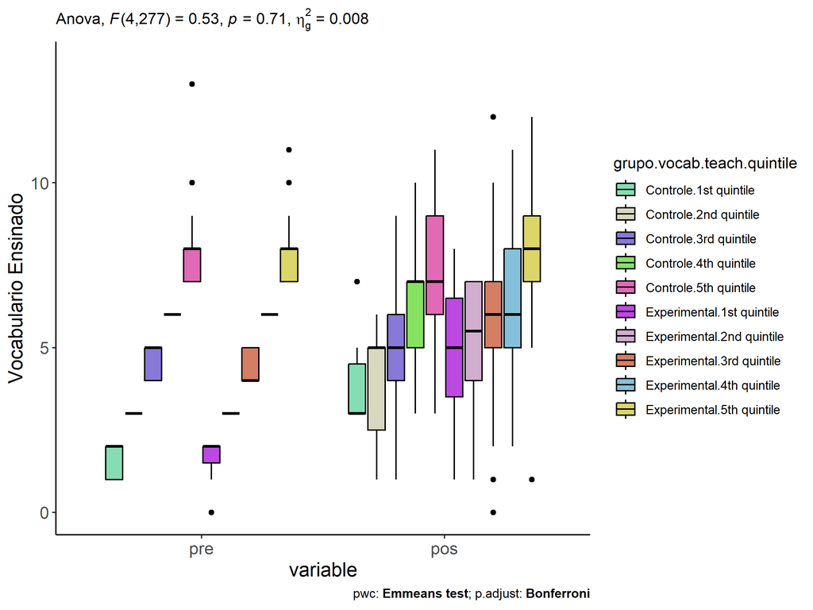

```r
plots[["grupo:vocab.teach.quintile"]] + ggplot2::ylab("Vocabulario Ensinado") + ggplot2::scale_x_discrete(labels=c('pre', 'pos'))
```

```r
plots <- twoWayAncovaBoxPlots(
  wdat.long, "vocab.teach", c("grupo","vocab.teach.quintile"), aov, pwc.long, pre.post = "time",
  theme = "classic", color = color$prepost)
```

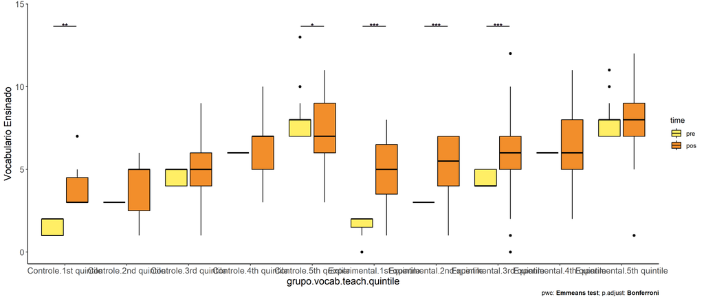

```r
plots[["grupo:vocab.teach.quintile"]] + ggplot2::ylab("Vocabulario Ensinado")
```

### Checking linearity assumption

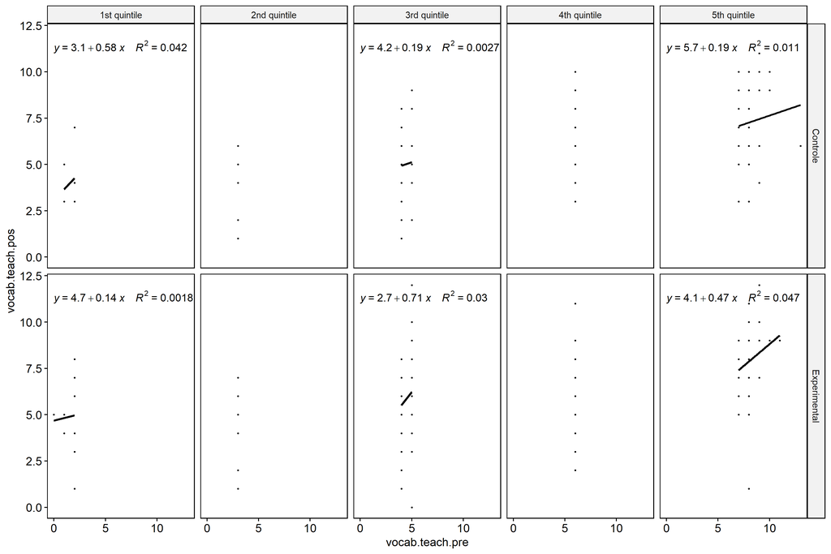

```r
ggscatter(wdat, x = "vocab.teach.pre", y = "vocab.teach.pos", size = 0.5,
          facet.by = c("grupo","vocab.teach.quintile"), add = "reg.line")+
  stat_regline_equation(
    aes(label =  paste(..eq.label.., ..rr.label.., sep = "~~~~"))
  )
```

### Checking normality and homogeneity

```r
res <- augment(lm(vocab.teach.pos ~ vocab.teach.pre + grupo*vocab.teach.quintile, data = wdat))
```

```r
shapiro_test(res$.resid)
```

```
## # A tibble: 1 × 3
##   variable   statistic p.value
##   <chr>          <dbl>   <dbl>
## 1 res$.resid     0.992   0.130
```

```r
levene_test(res, .resid ~ grupo*vocab.teach.quintile)
```

```
## # A tibble: 1 × 4
##     df1   df2 statistic     p
##   <int> <int>     <dbl> <dbl>
## 1     9   278     0.503 0.872
```

# Summary of Results

## Descriptive Statistics

```r
df <- get.descriptives(ldat[["grupo"]], c(dv.pre, dv.pos), c("grupo"),
                       include.global = T, symmetry.test = T, normality.test = F)
df <- plyr::rbind.fill(
  df, do.call(plyr::rbind.fill, lapply(lfatores2, FUN = function(f) {
    if (nrow(dat) > 0 && sum(!is.na(unique(dat[[f]]))) > 1)
      get.descriptives(ldat[[paste0("grupo:",f)]], c(dv.pre,dv.pos), c("grupo", f),
                       symmetry.test = T, normality.test = F)
    }))
)
(df <- df[,c(fatores1[fatores1 %in% colnames(df)],"variable",
             colnames(df)[!colnames(df) %in% c(fatores1,"variable")])])
```

```
##           grupo Sexo   Zona Cor.Raca vocab.teach.quintile        variable   n  mean median min max    sd    se
## 1      Controle <NA>   <NA>     <NA>                 <NA> vocab.teach.pre 117 5.821    6.0   1  13 2.116 0.196
## 2  Experimental <NA>   <NA>     <NA>                 <NA> vocab.teach.pre 170 5.224    5.0   0  11 1.933 0.148
## 3          <NA> <NA>   <NA>     <NA>                 <NA> vocab.teach.pre 287 5.467    5.0   0  13 2.027 0.120
## 4      Controle <NA>   <NA>     <NA>                 <NA> vocab.teach.pos 117 5.991    6.0   1  11 2.219 0.205
## 5  Experimental <NA>   <NA>     <NA>                 <NA> vocab.teach.pos 170 6.353    6.0   1  12 2.163 0.166
## 6          <NA> <NA>   <NA>     <NA>                 <NA> vocab.teach.pos 287 6.206    6.0   1  12 2.189 0.129
## 7      Controle    F   <NA>     <NA>                 <NA> vocab.teach.pre  55 5.618    6.0   1   9 1.967 0.265
## 8      Controle    M   <NA>     <NA>                 <NA> vocab.teach.pre  62 6.000    6.0   1  13 2.240 0.284
## 9  Experimental    F   <NA>     <NA>                 <NA> vocab.teach.pre  86 5.221    5.0   0  10 1.887 0.204
## 10 Experimental    M   <NA>     <NA>                 <NA> vocab.teach.pre  85 5.224    5.0   1  11 1.978 0.215
## 11     Controle    F   <NA>     <NA>                 <NA> vocab.teach.pos  55 5.945    6.0   1  10 2.181 0.294
## 12     Controle    M   <NA>     <NA>                 <NA> vocab.teach.pos  62 6.032    6.0   1  11 2.269 0.288
## 13 Experimental    F   <NA>     <NA>                 <NA> vocab.teach.pos  86 6.651    7.0   2  12 2.168 0.234
## 14 Experimental    M   <NA>     <NA>                 <NA> vocab.teach.pos  85 5.976    6.0   0  12 2.215 0.240
```

[output cut: 87 more lines]

| grupo | Sexo | Zona | Cor.Raca | vocab.teach.quintile | variable | n | mean | median | min | max | sd | se | ci | iqr | symmetry | skewness | kurtosis |
| --- | --- | --- | --- | --- | --- | --- | --- | --- | --- | --- | --- | --- | --- | --- | --- | --- | --- |
| Controle |  |  |  |  | vocab.teach.pre | 117 | 5.821 | 6.0 | 1 | 13 | 2.116 | 0.196 | 0.387 | 3.00 | YES | 0.034 | 0.227 |
| Experimental |  |  |  |  | vocab.teach.pre | 170 | 5.224 | 5.0 | 0 | 11 | 1.933 | 0.148 | 0.293 | 3.00 | YES | 0.168 | -0.254 |
|  |  |  |  |  | vocab.teach.pre | 287 | 5.467 | 5.0 | 0 | 13 | 2.027 | 0.120 | 0.236 | 3.00 | YES | 0.141 | 0.001 |
| Controle |  |  |  |  | vocab.teach.pos | 117 | 5.991 | 6.0 | 1 | 11 | 2.219 | 0.205 | 0.406 | 2.00 | YES | 0.062 | -0.525 |
| Experimental |  |  |  |  | vocab.teach.pos | 170 | 6.353 | 6.0 | 1 | 12 | 2.163 | 0.166 | 0.328 | 3.00 | YES | -0.121 | 0.000 |
|  |  |  |  |  | vocab.teach.pos | 287 | 6.206 | 6.0 | 1 | 12 | 2.189 | 0.129 | 0.254 | 3.00 | YES | -0.049 | -0.231 |
| Controle | F |  |  |  | vocab.teach.pre | 55 | 5.618 | 6.0 | 1 | 9 | 1.967 | 0.265 | 0.532 | 3.00 | YES | -0.317 | -0.423 |
| Controle | M |  |  |  | vocab.teach.pre | 62 | 6.000 | 6.0 | 1 | 13 | 2.240 | 0.284 | 0.569 | 3.75 | YES | 0.189 | 0.288 |
| Experimental | F |  |  |  | vocab.teach.pre | 86 | 5.221 | 5.0 | 0 | 10 | 1.887 | 0.204 | 0.405 | 2.00 | YES | -0.015 | -0.055 |
| Experimental | M |  |  |  | vocab.teach.pre | 85 | 5.224 | 5.0 | 1 | 11 | 1.978 | 0.215 | 0.427 | 3.00 | YES | 0.331 | -0.463 |
| Controle | F |  |  |  | vocab.teach.pos | 55 | 5.945 | 6.0 | 1 | 10 | 2.181 | 0.294 | 0.590 | 2.50 | YES | 0.195 | -0.482 |
| Controle | M |  |  |  | vocab.teach.pos | 62 | 6.032 | 6.0 | 1 | 11 | 2.269 | 0.288 | 0.576 | 3.00 | YES | -0.047 | -0.622 |
| Experimental | F |  |  |  | vocab.teach.pos | 86 | 6.651 | 7.0 | 2 | 12 | 2.168 | 0.234 | 0.465 | 3.00 | YES | 0.016 | -0.446 |
| Experimental | M |  |  |  | vocab.teach.pos | 85 | 5.976 | 6.0 | 0 | 12 | 2.215 | 0.240 | 0.478 | 2.00 | YES | -0.400 | 0.330 |
| Controle |  | Rural |  |  | vocab.teach.pre | 40 | 5.875 | 6.0 | 1 | 9 | 1.897 | 0.300 | 0.607 | 2.00 | NO | -0.704 | -0.114 |
| Controle |  | Urbana |  |  | vocab.teach.pre | 18 | 6.056 | 6.0 | 3 | 10 | 1.798 | 0.424 | 0.894 | 2.00 | YES | 0.266 | -0.704 |
| Experimental |  | Rural |  |  | vocab.teach.pre | 61 | 5.377 | 5.0 | 0 | 9 | 1.993 | 0.255 | 0.510 | 3.00 | YES | -0.244 | -0.302 |
| Experimental |  | Urbana |  |  | vocab.teach.pre | 43 | 5.419 | 5.0 | 2 | 11 | 2.152 | 0.328 | 0.662 | 3.00 | YES | 0.319 | -0.688 |
| Controle |  | Rural |  |  | vocab.teach.pos | 40 | 6.950 | 7.0 | 2 | 10 | 2.112 | 0.334 | 0.675 | 3.25 | YES | -0.382 | -0.497 |
| Controle |  | Urbana |  |  | vocab.teach.pos | 18 | 5.667 | 6.0 | 2 | 10 | 2.249 | 0.530 | 1.118 | 2.50 | YES | 0.159 | -0.755 |
| Experimental |  | Rural |  |  | vocab.teach.pos | 61 | 6.574 | 7.0 | 0 | 12 | 2.334 | 0.299 | 0.598 | 3.00 | YES | -0.417 | 0.276 |
| Experimental |  | Urbana |  |  | vocab.teach.pos | 43 | 6.116 | 6.0 | 3 | 10 | 1.854 | 0.283 | 0.571 | 2.00 | YES | 0.031 | -0.881 |
| Controle |  |  | Branca |  | vocab.teach.pre | 7 | 6.571 | 6.0 | 5 | 9 | 1.272 | 0.481 | 1.177 | 1.00 | NO | 0.696 | -0.751 |
| Controle |  |  | Parda |  | vocab.teach.pre | 44 | 5.364 | 5.0 | 1 | 13 | 2.393 | 0.361 | 0.727 | 3.00 | NO | 0.603 | 0.824 |
| Experimental |  |  | Branca |  | vocab.teach.pre | 13 | 5.769 | 6.0 | 3 | 8 | 1.739 | 0.482 | 1.051 | 3.00 | YES | -0.025 | -1.590 |
| Experimental |  |  | Parda |  | vocab.teach.pre | 52 | 4.942 | 5.0 | 0 | 9 | 2.155 | 0.299 | 0.600 | 3.00 | YES | 0.234 | -0.627 |
| Controle |  |  | Branca |  | vocab.teach.pos | 7 | 8.000 | 8.0 | 5 | 11 | 1.826 | 0.690 | 1.689 | 1.00 | YES | 0.000 | -0.891 |
| Controle |  |  | Parda |  | vocab.teach.pos | 44 | 5.773 | 6.0 | 1 | 10 | 2.208 | 0.333 | 0.671 | 2.25 | YES | 0.332 | -0.201 |
| Experimental |  |  | Branca |  | vocab.teach.pos | 13 | 7.231 | 7.0 | 5 | 10 | 1.922 | 0.533 | 1.161 | 3.00 | YES | 0.219 | -1.712 |
| Experimental |  |  | Parda |  | vocab.teach.pos | 52 | 6.212 | 6.0 | 0 | 12 | 2.667 | 0.370 | 0.742 | 4.00 | YES | 0.045 | -0.302 |
| Controle |  |  |  | 1st quintile | vocab.teach.pre | 7 | 1.571 | 2.0 | 1 | 2 | 0.535 | 0.202 | 0.494 | 1.00 | few data | 0.000 | 0.000 |
| Controle |  |  |  | 2nd quintile | vocab.teach.pre | 10 | 3.000 | 3.0 | 3 | 3 | 0.000 | 0.000 | 0.000 | 0.00 | few data | 0.000 | 0.000 |
| Controle |  |  |  | 3rd quintile | vocab.teach.pre | 31 | 4.548 | 5.0 | 4 | 5 | 0.506 | 0.091 | 0.186 | 1.00 | few data | 0.000 | 0.000 |
| Controle |  |  |  | 4th quintile | vocab.teach.pre | 25 | 6.000 | 6.0 | 6 | 6 | 0.000 | 0.000 | 0.000 | 0.00 | few data | 0.000 | 0.000 |
| Controle |  |  |  | 5th quintile | vocab.teach.pre | 44 | 7.932 | 8.0 | 7 | 13 | 1.149 | 0.173 | 0.349 | 1.00 | NO | 2.106 | 6.351 |
| Experimental |  |  |  | 1st quintile | vocab.teach.pre | 11 | 1.636 | 2.0 | 0 | 2 | 0.674 | 0.203 | 0.453 | 0.50 | few data | 0.000 | 0.000 |
| Experimental |  |  |  | 2nd quintile | vocab.teach.pre | 18 | 3.000 | 3.0 | 3 | 3 | 0.000 | 0.000 | 0.000 | 0.00 | few data | 0.000 | 0.000 |
| Experimental |  |  |  | 3rd quintile | vocab.teach.pre | 71 | 4.451 | 4.0 | 4 | 5 | 0.501 | 0.059 | 0.119 | 1.00 | few data | 0.000 | 0.000 |
| Experimental |  |  |  | 4th quintile | vocab.teach.pre | 25 | 6.000 | 6.0 | 6 | 6 | 0.000 | 0.000 | 0.000 | 0.00 | few data | 0.000 | 0.000 |
| Experimental |  |  |  | 5th quintile | vocab.teach.pre | 46 | 7.717 | 8.0 | 7 | 11 | 0.886 | 0.131 | 0.263 | 1.00 | NO | 1.500 | 2.645 |
| Controle |  |  |  | 1st quintile | vocab.teach.pos | 7 | 4.000 | 3.0 | 3 | 7 | 1.528 | 0.577 | 1.413 | 1.50 | NO | 0.962 | -0.743 |
| Controle |  |  |  | 2nd quintile | vocab.teach.pos | 10 | 4.000 | 5.0 | 1 | 6 | 1.700 | 0.537 | 1.216 | 2.50 | NO | -0.611 | -1.394 |
| Controle |  |  |  | 3rd quintile | vocab.teach.pos | 31 | 5.032 | 5.0 | 1 | 9 | 1.835 | 0.329 | 0.673 | 2.00 | YES | -0.171 | -0.242 |
| Controle |  |  |  | 4th quintile | vocab.teach.pos | 25 | 6.320 | 7.0 | 3 | 10 | 1.865 | 0.373 | 0.770 | 2.00 | YES | -0.006 | -1.055 |
| Controle |  |  |  | 5th quintile | vocab.teach.pos | 44 | 7.250 | 7.0 | 3 | 11 | 2.036 | 0.307 | 0.619 | 3.00 | YES | -0.090 | -0.916 |
| Experimental |  |  |  | 1st quintile | vocab.teach.pos | 11 | 4.909 | 5.0 | 1 | 8 | 2.212 | 0.667 | 1.486 | 3.00 | YES | -0.048 | -1.235 |
| Experimental |  |  |  | 2nd quintile | vocab.teach.pos | 18 | 5.333 | 5.5 | 1 | 7 | 1.879 | 0.443 | 0.934 | 3.00 | NO | -0.760 | -0.544 |
| Experimental |  |  |  | 3rd quintile | vocab.teach.pos | 71 | 5.831 | 6.0 | 0 | 12 | 2.042 | 0.242 | 0.483 | 2.00 | YES | 0.047 | 0.827 |
| Experimental |  |  |  | 4th quintile | vocab.teach.pos | 25 | 6.400 | 6.0 | 2 | 11 | 2.198 | 0.440 | 0.907 | 3.00 | YES | -0.244 | -0.364 |
| Experimental |  |  |  | 5th quintile | vocab.teach.pos | 46 | 7.739 | 8.0 | 1 | 12 | 1.914 | 0.282 | 0.568 | 2.00 | NO | -0.751 | 1.729 |

## ANCOVA Table Comparison

```r
df <- do.call(plyr::rbind.fill, laov)
(df <- df[!duplicated(df$Effect),])
```

```
##                        Effect DFn DFd      F        p p<.05   ges DFn' DFd'     F'       p' p<.05'  ges'
## 1                       grupo   1 284  8.301 4.00e-03     * 0.028    1  286  5.079 2.50e-02      * 0.017
## 2             vocab.teach.pre   1 284 84.483 8.51e-18     * 0.229    1  286 74.363 4.54e-16      * 0.206
## 4                  grupo:Sexo   1 283  1.452 2.29e-01       0.005    1  284  0.676 4.12e-01        0.002
## 5                        Sexo   1 283  3.821 5.20e-02       0.013    1  284  4.688 3.10e-02      * 0.016
## 8                  grupo:Zona   1 157  2.101 1.49e-01       0.013    1  158  2.812 9.60e-02        0.017
## 10                       Zona   1 157  7.037 9.00e-03     * 0.043    1  158  7.390 7.00e-03      * 0.045
## 11                   Cor.Raca   1 111  3.283 7.30e-02       0.029    1  111  3.283 7.30e-02        0.029
## 13             grupo:Cor.Raca   1 111  0.877 3.51e-01       0.008    1  111  0.877 3.51e-01        0.008
## 16 grupo:vocab.teach.quintile   4 277  0.530 7.14e-01       0.008    4  278  0.430 7.87e-01        0.006
## 18       vocab.teach.quintile   4 277  0.681 6.06e-01       0.010    4  278  0.397 8.10e-01        0.006
```

|  | Effect | DFn | DFd | F | p | p<.05 | ges | DFn’ | DFd’ | F’ | p’ | p<.05’ | ges’ |
| --- | --- | --- | --- | --- | --- | --- | --- | --- | --- | --- | --- | --- | --- |
| 1 | grupo | 1 | 284 | 8.301 | 0.004 | * | 0.028 | 1 | 286 | 5.079 | 0.025 | * | 0.017 |
| 2 | vocab.teach.pre | 1 | 284 | 84.483 | 0.000 | * | 0.229 | 1 | 286 | 74.363 | 0.000 | * | 0.206 |
| 4 | grupo:Sexo | 1 | 283 | 1.452 | 0.229 |  | 0.005 | 1 | 284 | 0.676 | 0.412 |  | 0.002 |
| 5 | Sexo | 1 | 283 | 3.821 | 0.052 |  | 0.013 | 1 | 284 | 4.688 | 0.031 | * | 0.016 |
| 8 | grupo:Zona | 1 | 157 | 2.101 | 0.149 |  | 0.013 | 1 | 158 | 2.812 | 0.096 |  | 0.017 |
| 10 | Zona | 1 | 157 | 7.037 | 0.009 | * | 0.043 | 1 | 158 | 7.390 | 0.007 | * | 0.045 |
| 11 | Cor.Raca | 1 | 111 | 3.283 | 0.073 |  | 0.029 | 1 | 111 | 3.283 | 0.073 |  | 0.029 |
| 13 | grupo:Cor.Raca | 1 | 111 | 0.877 | 0.351 |  | 0.008 | 1 | 111 | 0.877 | 0.351 |  | 0.008 |
| 16 | grupo:vocab.teach.quintile | 4 | 277 | 0.530 | 0.714 |  | 0.008 | 4 | 278 | 0.430 | 0.787 |  | 0.006 |
| 18 | vocab.teach.quintile | 4 | 277 | 0.681 | 0.606 |  | 0.010 | 4 | 278 | 0.397 | 0.810 |  | 0.006 |

## PairWise Table Comparison

```r
df <- do.call(plyr::rbind.fill, lpwc)
df <- df[,c(names(lfatores), names(df)[!names(df) %in% c(names(lfatores),"term",".y.")])]
```

| grupo | Sexo | Zona | Cor.Raca | vocab.teach.quintile | group1 | group2 | df | statistic | p | p.adj | p.adj.signif | df’ | statistic’ | p’ | p.adj’ | p.adj.signif’ |
| --- | --- | --- | --- | --- | --- | --- | --- | --- | --- | --- | --- | --- | --- | --- | --- | --- |
| Controle |  |  |  |  | pre | pos | 570 | -0.623 | 0.534 | 0.534 | ns | 574 | -0.912 | 0.362 | 0.362 | ns |
| Experimental |  |  |  |  | pre | pos | 570 | -4.960 | 0.000 | 0.000 | **** | 574 | -4.721 | 0.000 | 0.000 | **** |
|  |  |  |  |  | Controle | Experimental | 284 | -2.881 | 0.004 | 0.004 | ** | 286 | -2.254 | 0.025 | 0.025 | * |
| Controle | F |  |  |  | pre | pos | 568 | -0.813 | 0.416 | 0.416 | ns | 570 | -1.236 | 0.217 | 0.217 | ns |
| Controle | M |  |  |  | pre | pos | 568 | -0.085 | 0.932 | 0.932 | ns | 570 | -0.084 | 0.933 | 0.933 | ns |
| Controle |  |  |  |  | F | M | 283 | 0.313 | 0.754 | 0.754 | ns | 284 | 0.748 | 0.455 | 0.455 | ns |
| Experimental | F |  |  |  | pre | pos | 568 | -4.445 | 0.000 | 0.000 | **** | 570 | -4.383 | 0.000 | 0.000 | **** |
| Experimental | M |  |  |  | pre | pos | 568 | -2.326 | 0.020 | 0.020 | * | 570 | -2.294 | 0.022 | 0.022 | * |
| Experimental |  |  |  |  | F | M | 283 | 2.275 | 0.024 | 0.024 | * | 284 | 2.192 | 0.029 | 0.029 | * |
|  | F |  |  |  | Controle | Experimental | 283 | -2.717 | 0.007 | 0.007 | ** | 284 | -2.145 | 0.033 | 0.033 | * |
|  | M |  |  |  | Controle | Experimental | 283 | -1.070 | 0.285 | 0.285 | ns | 284 | -1.020 | 0.309 | 0.309 | ns |
| Controle |  |  |  |  | Rural | Urbana | 157 | 2.710 | 0.007 | 0.007 | ** | 158 | 2.936 | 0.004 | 0.004 | ** |
| Controle |  | Rural |  |  | pre | pos | 316 | -2.318 | 0.021 | 0.021 | * | 318 | -2.767 | 0.006 | 0.006 | ** |
| Controle |  | Urbana |  |  | pre | pos | 316 | 0.563 | 0.574 | 0.574 | ns | 318 | 0.551 | 0.582 | 0.582 | ns |
| Experimental |  |  |  |  | Rural | Urbana | 157 | 1.340 | 0.182 | 0.182 | ns | 158 | 1.258 | 0.210 | 0.210 | ns |
| Experimental |  | Rural |  |  | pre | pos | 316 | -3.187 | 0.002 | 0.002 | ** | 318 | -3.124 | 0.002 | 0.002 | ** |
| Experimental |  | Urbana |  |  | pre | pos | 316 | -1.560 | 0.120 | 0.120 | ns | 318 | -1.529 | 0.127 | 0.127 | ns |
|  |  | Rural |  |  | Controle | Experimental | 157 | 0.223 | 0.824 | 0.824 | ns | 158 | 0.761 | 0.448 | 0.448 | ns |
|  |  | Urbana |  |  | Controle | Experimental | 157 | -1.621 | 0.107 | 0.107 | ns | 158 | -1.510 | 0.133 | 0.133 | ns |
| Controle |  |  | Branca |  | pre | pos | 224 | -1.172 | 0.243 | 0.243 | ns | 224 | -1.172 | 0.243 | 0.243 | ns |
| Controle |  |  |  |  | Branca | Parda | 111 | 1.847 | 0.067 | 0.067 | ns | 111 | 1.847 | 0.067 | 0.067 | ns |
| Controle |  |  | Parda |  | pre | pos | 224 | -0.841 | 0.401 | 0.401 | ns | 224 | -0.841 | 0.401 | 0.401 | ns |
| Experimental |  |  | Branca |  | pre | pos | 224 | -1.633 | 0.104 | 0.104 | ns | 224 | -1.633 | 0.104 | 0.104 | ns |
| Experimental |  |  |  |  | Branca | Parda | 111 | 0.892 | 0.374 | 0.374 | ns | 111 | 0.892 | 0.374 | 0.374 | ns |
| Experimental |  |  | Parda |  | pre | pos | 224 | -2.837 | 0.005 | 0.005 | ** | 224 | -2.837 | 0.005 | 0.005 | ** |
|  |  |  | Branca |  | Controle | Experimental | 111 | 0.353 | 0.725 | 0.725 | ns | 111 | 0.353 | 0.725 | 0.725 | ns |
|  |  |  | Parda |  | Controle | Experimental | 111 | -1.523 | 0.131 | 0.131 | ns | 111 | -1.523 | 0.131 | 0.131 | ns |
| Controle |  |  |  | 1st quintile | pre | pos | 556 | -3.082 | 0.002 | 0.002 | ** | 558 | -2.972 | 0.003 | 0.003 | ** |
| Controle |  |  |  | 2nd quintile | pre | pos | 556 | -1.517 | 0.130 | 0.130 | ns | 558 | -1.462 | 0.144 | 0.144 | ns |
| Controle |  |  |  | 3rd quintile | pre | pos | 556 | -1.292 | 0.197 | 0.197 | ns | 558 | -2.044 | 0.041 | 0.041 | * |
| Controle |  |  |  | 4th quintile | pre | pos | 556 | -0.768 | 0.443 | 0.443 | ns | 558 | -0.740 | 0.460 | 0.460 | ns |
| Controle |  |  |  | 5th quintile | pre | pos | 556 | 2.170 | 0.030 | 0.030 | * | 558 | 2.092 | 0.037 | 0.037 | * |
| Controle |  |  |  |  | 1st quintile | 2nd quintile | 277 | 0.495 | 0.621 | 1.000 | ns | 278 | 0.523 | 0.601 | 1.000 | ns |
| Controle |  |  |  |  | 1st quintile | 3rd quintile | 277 | 0.000 | 1.000 | 1.000 | ns | 278 | -0.200 | 0.841 | 1.000 | ns |
| Controle |  |  |  |  | 1st quintile | 4th quintile | 277 | -0.684 | 0.495 | 1.000 | ns | 278 | -0.529 | 0.598 | 1.000 | ns |
| Controle |  |  |  |  | 1st quintile | 5th quintile | 277 | -0.758 | 0.449 | 1.000 | ns | 278 | -0.575 | 0.566 | 1.000 | ns |
| Controle |  |  |  |  | 2nd quintile | 3rd quintile | 277 | -0.648 | 0.518 | 1.000 | ns | 278 | -0.941 | 0.347 | 1.000 | ns |
| Controle |  |  |  |  | 2nd quintile | 4th quintile | 277 | -1.412 | 0.159 | 1.000 | ns | 278 | -1.247 | 0.213 | 1.000 | ns |
| Controle |  |  |  |  | 2nd quintile | 5th quintile | 277 | -1.387 | 0.167 | 1.000 | ns | 278 | -1.185 | 0.237 | 1.000 | ns |
| Controle |  |  |  |  | 3rd quintile | 4th quintile | 277 | -1.336 | 0.183 | 1.000 | ns | 278 | -0.706 | 0.481 | 1.000 | ns |
| Controle |  |  |  |  | 3rd quintile | 5th quintile | 277 | -1.384 | 0.167 | 1.000 | ns | 278 | -0.796 | 0.426 | 1.000 | ns |
| Controle |  |  |  |  | 4th quintile | 5th quintile | 277 | -0.435 | 0.664 | 1.000 | ns | 278 | -0.310 | 0.757 | 1.000 | ns |
| Experimental |  |  |  | 1st quintile | pre | pos | 556 | -5.207 | 0.000 | 0.000 | **** | 558 | -5.020 | 0.000 | 0.000 | **** |
| Experimental |  |  |  | 2nd quintile | pre | pos | 556 | -4.749 | 0.000 | 0.000 | **** | 558 | -4.578 | 0.000 | 0.000 | **** |
| Experimental |  |  |  | 3rd quintile | pre | pos | 556 | -5.579 | 0.000 | 0.000 | **** | 558 | -5.379 | 0.000 | 0.000 | **** |
| Experimental |  |  |  | 4th quintile | pre | pos | 556 | -0.959 | 0.338 | 0.338 | ns | 558 | -0.925 | 0.355 | 0.355 | ns |
| Experimental |  |  |  | 5th quintile | pre | pos | 556 | -0.071 | 0.944 | 0.944 | ns | 558 | -0.068 | 0.946 | 0.946 | ns |
| Experimental |  |  |  |  | 1st quintile | 2nd quintile | 277 | 0.061 | 0.951 | 1.000 | ns | 278 | 0.116 | 0.907 | 1.000 | ns |
| Experimental |  |  |  |  | 1st quintile | 3rd quintile | 277 | 0.066 | 0.947 | 1.000 | ns | 278 | 0.180 | 0.857 | 1.000 | ns |
| Experimental |  |  |  |  | 1st quintile | 4th quintile | 277 | 0.021 | 0.984 | 1.000 | ns | 278 | 0.158 | 0.874 | 1.000 | ns |
| Experimental |  |  |  |  | 1st quintile | 5th quintile | 277 | -0.573 | 0.567 | 1.000 | ns | 278 | -0.390 | 0.697 | 1.000 | ns |
| Experimental |  |  |  |  | 2nd quintile | 3rd quintile | 277 | 0.009 | 0.993 | 1.000 | ns | 278 | 0.092 | 0.927 | 1.000 | ns |
| Experimental |  |  |  |  | 2nd quintile | 4th quintile | 277 | -0.033 | 0.974 | 1.000 | ns | 278 | 0.092 | 0.927 | 1.000 | ns |
| Experimental |  |  |  |  | 2nd quintile | 5th quintile | 277 | -0.773 | 0.440 | 1.000 | ns | 278 | -0.586 | 0.559 | 1.000 | ns |
| Experimental |  |  |  |  | 3rd quintile | 4th quintile | 277 | -0.060 | 0.952 | 1.000 | ns | 278 | 0.039 | 0.969 | 1.000 | ns |
| Experimental |  |  |  |  | 3rd quintile | 5th quintile | 277 | -1.130 | 0.260 | 1.000 | ns | 278 | -0.928 | 0.354 | 1.000 | ns |
| Experimental |  |  |  |  | 4th quintile | 5th quintile | 277 | -1.294 | 0.197 | 1.000 | ns | 278 | -1.144 | 0.254 | 1.000 | ns |
|  |  |  |  | 1st quintile | Controle | Experimental | 277 | -0.933 | 0.352 | 0.352 | ns | 278 | -0.894 | 0.372 | 0.372 | ns |
|  |  |  |  | 2nd quintile | Controle | Experimental | 277 | -1.720 | 0.086 | 0.086 | ns | 278 | -1.653 | 0.099 | 0.099 | ns |
|  |  |  |  | 3rd quintile | Controle | Experimental | 277 | -1.967 | 0.050 | 0.050 | ns | 278 | -1.216 | 0.225 | 0.225 | ns |
|  |  |  |  | 4th quintile | Controle | Experimental | 277 | -0.144 | 0.886 | 0.886 | ns | 278 | -0.138 | 0.890 | 0.890 | ns |
|  |  |  |  | 5th quintile | Controle | Experimental | 277 | -1.354 | 0.177 | 0.177 | ns | 278 | -1.318 | 0.188 | 0.188 | ns |

## EMMS Table Comparison

```r
df <- do.call(plyr::rbind.fill, lemms)
df[["N-N'"]] <- df[["N"]] - df[["N'"]]
df <- df[,c(names(lfatores), names(df)[!names(df) %in% names(lfatores)])]
```

| grupo | Sexo | Zona | Cor.Raca | vocab.teach.quintile | N | M (pre) | SE (pre) | M (unadj) | SE (unadj) | M (adj) | SE (adj) | N’ | M (pre)’ | SE (pre)’ | M (unadj)’ | SE (unadj)’ | M (adj)’ | SE (adj)’ | N-N’ |
| --- | --- | --- | --- | --- | --- | --- | --- | --- | --- | --- | --- | --- | --- | --- | --- | --- | --- | --- | --- |
| Controle |  |  |  |  | 117 | 5.821 | 0.196 | 5.991 | 0.205 | 5.807 | 0.179 | 118 | 5.814 | 0.194 | 6.068 | 0.217 | 5.887 | 0.188 | -1 |
| Experimental |  |  |  |  | 170 | 5.224 | 0.148 | 6.353 | 0.166 | 6.480 | 0.148 | 171 | 5.222 | 0.147 | 6.316 | 0.169 | 6.440 | 0.156 | -1 |
| Controle | F |  |  |  | 55 | 5.618 | 0.265 | 5.945 | 0.294 | 5.865 | 0.262 | 56 | 5.607 | 0.261 | 6.107 | 0.331 | 6.033 | 0.270 | -1 |
| Controle | M |  |  |  | 62 | 6.000 | 0.284 | 6.032 | 0.288 | 5.752 | 0.249 | 62 | 6.000 | 0.284 | 6.032 | 0.288 | 5.754 | 0.258 | 0 |
| Experimental | F |  |  |  | 86 | 5.221 | 0.204 | 6.651 | 0.234 | 6.779 | 0.210 | 86 | 5.221 | 0.204 | 6.651 | 0.234 | 6.777 | 0.218 | 0 |
| Experimental | M |  |  |  | 85 | 5.224 | 0.215 | 5.976 | 0.240 | 6.103 | 0.211 | 85 | 5.224 | 0.215 | 5.976 | 0.240 | 6.101 | 0.219 | 0 |
| Controle |  | Rural |  |  | 40 | 5.875 | 0.300 | 6.950 | 0.334 | 6.780 | 0.286 | 41 | 5.854 | 0.293 | 7.146 | 0.380 | 6.990 | 0.301 | -1 |
| Controle |  | Urbana |  |  | 18 | 6.056 | 0.424 | 5.667 | 0.530 | 5.390 | 0.427 | 18 | 6.056 | 0.424 | 5.667 | 0.530 | 5.393 | 0.455 | 0 |
| Experimental |  | Rural |  |  | 61 | 5.377 | 0.255 | 6.574 | 0.299 | 6.697 | 0.232 | 61 | 5.377 | 0.255 | 6.574 | 0.299 | 6.693 | 0.247 | 0 |
| Experimental |  | Urbana |  |  | 43 | 5.419 | 0.328 | 6.116 | 0.283 | 6.215 | 0.276 | 43 | 5.419 | 0.328 | 6.116 | 0.283 | 6.211 | 0.293 | 0 |
| Controle |  |  | Branca |  | 7 | 6.571 | 0.481 | 8.000 | 0.690 | 7.331 | 0.804 | 7 | 6.571 | 0.481 | 8.000 | 0.690 | 7.331 | 0.804 | 0 |
| Controle |  |  | Parda |  | 44 | 5.364 | 0.361 | 5.773 | 0.333 | 5.736 | 0.317 | 44 | 5.364 | 0.361 | 5.773 | 0.333 | 5.736 | 0.317 | 0 |
| Experimental |  |  | Branca |  | 13 | 5.769 | 0.482 | 7.231 | 0.533 | 6.982 | 0.585 | 13 | 5.769 | 0.482 | 7.231 | 0.533 | 6.982 | 0.585 | 0 |
| Experimental |  |  | Parda |  | 52 | 4.942 | 0.299 | 6.212 | 0.370 | 6.395 | 0.294 | 52 | 4.942 | 0.299 | 6.212 | 0.370 | 6.395 | 0.294 | 0 |
| Controle |  |  |  | 1st quintile | 7 | 1.571 | 0.202 | 4.000 | 0.577 | 5.350 | 1.012 | 7 | 1.571 | 0.202 | 4.000 | 0.577 | 5.484 | 1.053 | 0 |
| Controle |  |  |  | 2nd quintile | 10 | 3.000 | 0.000 | 4.000 | 0.537 | 4.855 | 0.759 | 10 | 3.000 | 0.000 | 4.000 | 0.537 | 4.939 | 0.789 | 0 |
| Controle |  |  |  | 3rd quintile | 31 | 4.548 | 0.091 | 5.032 | 0.329 | 5.350 | 0.388 | 32 | 4.562 | 0.089 | 5.344 | 0.446 | 5.687 | 0.398 | -1 |
| Controle |  |  |  | 4th quintile | 25 | 6.000 | 0.000 | 6.320 | 0.373 | 6.135 | 0.404 | 25 | 6.000 | 0.000 | 6.320 | 0.373 | 6.116 | 0.421 | 0 |
| Controle |  |  |  | 5th quintile | 44 | 7.932 | 0.173 | 7.250 | 0.307 | 6.395 | 0.527 | 44 | 7.932 | 0.173 | 7.250 | 0.307 | 6.309 | 0.548 | 0 |
| Experimental |  |  |  | 1st quintile | 11 | 1.636 | 0.203 | 4.909 | 0.667 | 6.236 | 0.899 | 11 | 1.636 | 0.203 | 4.909 | 0.667 | 6.368 | 0.935 | 0 |
| Experimental |  |  |  | 2nd quintile | 18 | 3.000 | 0.000 | 5.333 | 0.443 | 6.188 | 0.636 | 18 | 3.000 | 0.000 | 5.333 | 0.443 | 6.273 | 0.661 | 0 |
| Experimental |  |  |  | 3rd quintile | 71 | 4.451 | 0.059 | 5.831 | 0.242 | 6.183 | 0.294 | 71 | 4.451 | 0.059 | 5.831 | 0.242 | 6.217 | 0.306 | 0 |
| Experimental |  |  |  | 4th quintile | 25 | 6.000 | 0.000 | 6.400 | 0.440 | 6.215 | 0.404 | 25 | 6.000 | 0.000 | 6.400 | 0.440 | 6.196 | 0.421 | 0 |
| Experimental |  |  |  | 5th quintile | 46 | 7.717 | 0.131 | 7.739 | 0.282 | 6.958 | 0.492 | 46 | 7.717 | 0.131 | 7.739 | 0.282 | 6.880 | 0.512 | 0 |